# Der Effekt von Earnings-Conference Calls am Aktienmarkt

# Motivation

Earnings Conference Calls sind zentrale Informationsereignisse in Finanzmärkten. Hier kommuniziert das Management direkt mit Investoren und Analysten über die aktuelle Geschäftslage und Zukunftsaussichten. Die finanzwirtschaftliche Forschung zeigt, dass diese Calls erhebliche Kursbewegungen auslösen können - doch die zugrundeliegenden Mechanismen sind noch nicht vollständig verstanden.

Während traditionelle Finanztheorie von effizienten Märkten ausgeht, die alle verfügbaren Informationen sofort verarbeiten, zeigen empirische Studien, dass die Art der Kommunikation und das Sentiment der Aussagen eigenständige Erklärungskraft für Aktienkursreaktionen besitzen. Diese Erkenntnisse haben direkte praktische Relevanz: Banken nutzen Sentiment-Analysen für algorithmische Handelsstrategien, Hedge Fonds entwickeln systematische Ansätze zur Textauswertung, und Asset Manager integrieren qualitative Informationen in ihre Bewertungsmodelle.

In diesem Projekt kombinieren Sie Event Studies - eine etablierte Methode der empirischen Finanzforschung zur Messung von Informationseffekten - mit modernen Large Language Models zur systematischen Textanalyse. Sie untersuchen, ob und wie sich qualitative Aussagen des Managements in quantifizierbaren Marktreaktionen niederschlagen, und lernen dabei sowohl die methodischen Grundlagen der Kausalitätsidentifikation als auch den praktischen Umgang mit KI-gestützten Finanzanalysen kennen.

# Event-Study-Methodik und theoretische Diskussion

1. Lesen Sie das Kapitel [“Event Studies” in Huntington-Klein (2021)](https://theeffectbook.net/ch-EventStudies.html) und beantworten Sie die folgenden Fragen dazu:

Kann eine Eventstudie helfen, den kausalen Effekt eines Earnings Conference Calls auf die Aktienrendite eines Unternehmens zu identifizieren? Gehen Sie bei der Beantwortung dieser Frage insbesondere auf die nachfolgenden Punkte ein:

- Welche Art von Variation nutzt eine Eventstudie zur Identifikation des Effekts?
- Welche Voraussetzung(en) müssen erfüllt sein, damit die Eventstudie eine gültige Kausalschätzung liefert?
  - Was bedeutet das “Joint-Test Problem” in diesem Kontext?

### Kann eine Eventstudie den kausalen Effekt eines Earnings Calls auf Aktienrenditen messen?

**Grundprinzip der Eventstudien-Methodik**

Ob eine Eventstudie den kausalen Effekt eines Earnings Conference Calls auf die Aktienrendite eines Unternehmens identifizieren kann, hängt stark von den zugrunde liegenden Annahmen und methodischen Voraussetzungen ab. Grundsätzlich basiert die Eventstudien-Methodik auf einem Vorher-Nachher-Vergleich: Sie nutzt die zeitliche Variation innerhalb derselben Beobachtungseinheit, also eines Unternehmens, um Veränderungen in der Rendite rund um ein spezifisches Ereignis zu analysieren. Dabei wird angenommen, dass man die Renditeentwicklung nach dem Event mit einem kontrafaktischen Verlauf vergleichen kann – also einer Prognose, wie sich die Rendite entwickelt hätte, wenn das Event nicht stattgefunden hätte.

**Voraussetzungen für eine gültige Kausalschätzung**

Damit eine solche Analyse als kausal interpretierbar gilt, müssen allerdings zwei zentrale Voraussetzungen erfüllt sein. Erstens darf es keine anderen gleichzeitigen Ereignisse geben, die die Aktienrendite beeinflussen könnten. Nur wenn ausgeschlossen werden kann, dass parallel zum Earnings Call beispielsweise makroökonomische Nachrichten, politische Entwicklungen oder andere unternehmensspezifische Informationen veröffentlicht wurden, lässt sich ein beobachteter Effekt eindeutig dem Earnings Call zuordnen. In der Realität ist diese Bedingung jedoch schwer zu erfüllen, da Kapitalmärkte permanent auf vielfältige Informationsquellen reagieren.

Zweitens muss der kontrafaktische Verlauf der Rendite realistisch geschätzt werden können. Das bedeutet, man muss plausibel davon ausgehen können, dass sich die Renditeentwicklung ohne das Event ähnlich fortgesetzt hätte wie in der vorangegangenen Periode. Dieser hypothetische Verlauf ist jedoch nicht beobachtbar, sondern muss anhand eines Modells konstruiert werden – beispielsweise durch einfache Trendfortschreibung oder durch Kontrolle für andere Einflussgrößen wie die allgemeine Marktentwicklung. Besonders bei sehr kurzen Zeitfenstern – wie typischerweise in Eventstudien verwendet – ist die Annahme eines stabilen, vorhersehbaren Verlaufs oft eher plausibel. Dennoch bleibt das Problem bestehen, dass schon kleine externe Impulse die Vergleichbarkeit stören können.

**Das Joint-Test Problem**

Ein zentrales methodisches Risiko stellt dabei das sogenannte Joint-Test-Problem dar: Bei jeder Eventstudie wird nicht nur der Effekt des Events selbst getestet, sondern gleichzeitig auch die Güte des verwendeten Prognosemodells. Wenn ein signifikanter Effekt beobachtet wird, lässt sich nicht ohne Weiteres sagen, ob dieser tatsächlich auf das Event zurückzuführen ist – oder ob er lediglich auf Fehler im kontrafaktischen Modell basiert. Modellunsicherheit und Effektmessung sind also untrennbar miteinander verbunden. Dies macht deutlich, wie wichtig eine sorgfältige Validierung des Modells ist, beispielsweise durch Placebo-Tests in Zeiträumen ohne Ereignis. Wenn sich auch dort „Effekte“ zeigen, spricht das eher für systematische Modellfehler als für echte Ereigniseffekte.

**Fazit: Informierte Korrelation statt eindeutiger Kausalschluss**

Insgesamt kann eine Eventstudie unter bestimmten Bedingungen durchaus zu kausalen Aussagen beitragen. Voraussetzung ist jedoch, dass die Marktreaktion eindeutig dem Event zugeordnet werden kann und der hypothetische Verlauf der Rendite ohne das Event valide modelliert wurde. In der Praxis ist dies nur selten vollkommen gegeben, weshalb die Ergebnisse solcher Studien eher als gut informierte Korrelationen denn als eindeutige Kausalschätzungen betrachtet werden sollten. Für robustere kausale Schlussfolgerungen sind zusätzliche methodische Absicherungen erforderlich, etwa durch differenziertere Kontrollvariablen, alternative Modelle oder quasi-experimentelle Designs.

# Daten und Datenaufbereitung

## Finanzmarktkennzahlen

2. Sie sollten in einem ersten Schritt Finanzkennzahlen aus Datastream herunterladen. Insbesondere sollten Sie den Return Index (RI) und die Total Assets (WC02999) für alle Firmen im Euro Stoxx 600 Technology Index ( wir haben Ihnen die RIC Kürzel in der Readme bereitgestellt ) vom 01.01.2020 bis heute extrahieren.

Bitte laden Sie für den Return Index tägliche Daten herunter und für die Total Assets Quartalsdaten. Weiterhin sollten Sie den Total Return Index (RI) des Euro Stoxx 600 (RIC = .STOXX) herunterladen (auch tägliche Daten). Bitte achten Sie darauf alle Daten **in Euro** herunterzuladen.

Achten Sie darauf die RIC als eindeutige Identifikationskennung in ihren Datensatz aufzunehmen.

Das Institut für Finanzwirtschaft der Universität Ulm hat einen ausführlichen [Guide zu Datastream](https://www.uni-ulm.de/fileadmin/website_uni_ulm/allgemein/Update_Introduction_Datastream_May_2025.pdf) erstellt, der Ihnen beim Download der Daten sicherlich helfen kann.

Die Universität Ulm stellt für den Download Remote-PCs zur Verfügung, auf die Sie sich von daheim aus einloggen können. Bitte buchen Sie sich hier einen Slot um Zugriff auf diese PCs zu erhalten: https://www.uni-ulm.de/mawi/iof/lehre/proposals-for-theses/datastream-and-workspace/

Sie sollten ihre Daten in Excel herunterladen und in ihrem Projekt im Unterordner `data` abspeichern.

*Hinweis 1:* Es empfiehlt sich zwei Tabellenblätter im Excel File anzulegen, eines für die täglichen Daten und eines für die Quartalsdaten

*Hinweis 2:* Datastream ist eine Datenbank, die Kennzahlen zur Finanzlage von börsennotierten Unternehmen weltweit beinhaltet. Die Lizenzen zu Datastream an der Universität Ulm werden von der Studienkommission Wirtschaftswissenschaften und der LBBW bezahlt und die Datenbank steht allen WiWi-Studierenden frei zur Verfügung. [Nähere Informationen zu Datastream finden Sie hier](https://www.uni-ulm.de/mawi/iof/lehre/proposals-for-theses/datastream-and-workspace/) (Bitte beachten: Sie müssen im Uninetz (z.B. über VPN) eingeloggt sein um die Informationen zu sehen und um sich auf die Remote-PCs loggen zu können).

*Hinweis 3:* Bei den Total Assets müssen Sie immer das Enddatum des vorherigen Jahres nehmen für den Download, d.h. Start Date wäre 31.12.2019

3. Lesen Sie die Excel Datei, welche Sie in Aufgabe 2 erstellt haben, in R ein. Achten Sie darauf, dass diese Daten tidy und richtig formatiert sind. Joinen Sie die täglichen Daten mit den Quartalsdaten für die relevanten Firmen. Die Quartalsdaten zählen für das komplette Quartal zu dem diese hinzugemerged wurden.

Setzen Sie sich mit den Aktienkursen auseinander und beantworten folgende Fragen: - Sie wollen in Aufgabe 4 *Renditen* berechnen, warum sollten Sie Daten zum “Total Return Index” und nicht dem “Price” oder “Unadjusted Price” herunterladen? Schauen Sie sich zur Klärung dieser Frage den [Guide der Uni Ulm zu Datastream](https://www.uni-ulm.de/fileadmin/website_uni_ulm/allgemein/Update_Introduction_Datastream_May_2025.pdf) genauer an. Diesen Guide sollten sie auch für den Download der Daten heranziehen.

*Hinweis:* In dem tidy Datensatz sollten Sie eine Spalte mit dem Unternehmensidentifier (RIC), eine mit dem Datum und eine mit der Variablen (RI bzw. Total Assets) haben

### Warum der Total Return Index (RI) die beste Basis für Renditeanalysen ist

**Bedeutung der richtigen Datenbasis**

Bei der Analyse von Aktienrenditen ist die Wahl des richtigen Datenformats entscheidend. Für verlässliche Berechnungen von Renditen sollten nicht einfach Kursdaten („Price“ oder „Unadjusted Price“) verwendet werden, sondern der sogenannte *Total Return Index* (RI). Dieser bietet gegenüber anderen Preisvarianten entscheidende Vorteile, wie im Datastream-Guide der Universität Ulm erläutert wird.

**Was ist der Total Return Index und warum wird er empfohlen?**

Der Total Return Index berücksichtigt sämtliche Erträge, die ein Anleger im Zeitverlauf erhalten hätte. Dazu zählen neben Kursgewinnen auch Dividendenzahlungen und Kapitalmaßnahmen wie Sonderausschüttungen oder Aktiensplits. Die Kennzahl RI spiegelt somit die tatsächliche Gesamtrendite wider, die ein Investor erzielen würde, wenn er alle Erträge direkt reinvestiert.

Der Datastream-Leitfaden der Universität Ulm empfiehlt ausdrücklich die Verwendung von RI für Rendite- und Volatilitätsanalysen. Dort heißt es:

*“Für die meisten Zwecke, wie beispielsweise die Ermittlung der Volatilität oder die Bewertung der Performance eines Investments, wird der Total Return Index (TRI) empfohlen. Wenn Sie stattdessen [P oder UP] verwenden, ist es wichtig, dass Sie gute Gründe für diese Entscheidung angeben.”*

RI liefert eine vollständige und verlässliche Grundlage zur Bewertung der Wertentwicklung einer Aktie aus Sicht eines Investors.

**Schwächen von Price (P) und Unadjusted Price (UP)**

Alternativ verfügbare Preisvarianten bieten deutlich weniger Aussagekraft im Hinblick auf die tatsächliche Performance einer Aktie:

- Price (P) ist ein an Splits und andere technische Ereignisse angepasster Preis, berücksichtigt jedoch keine Dividenden. Er eignet sich daher nur eingeschränkt zur Renditeberechnung.
- Unadjusted Price (UP) gibt den originalen historischen Kurswert wieder – ohne jegliche Anpassung für Splits oder Ausschüttungen. Dies ist beispielsweise hilfreich, um bestimmte Preisfilter anzuwenden (z.B. Ausschluss von Penny-Stocks), liefert aber keine valide Grundlage für Performanceanalysen.

**Fazit**

Nur der Total Return Index (RI) ermöglicht eine realistische und vergleichbare Erfassung der tatsächlichen Wertentwicklung einer Aktie. Für präzise Renditeberechnungen – wie sie etwa in Aufgabe 4 vorgesehen sind – ist daher ausschließlich RI als Datenbasis sinnvoll und methodisch korrekt.

## Renditen berechnen

4. In ihrem Datastream-Datensatz, welchen Sie in Aufgabe 2 bereits eingelesen und in Aufgabe 3 bearbeitet haben, sind die *Total Return Indices* (RI) der größten Unternehmen aus der Tech-Branche in Europa enthalten, sowie der *Total Return Indix* des Euro Stoxx 600. Der Euro Stoxx 600 ist ein großer, diversifizierter Aktienindex in Europa in dem die 600 größten Unternehmen gelistet sind. Sie sollten den Euro Stoxx 600 als Benchmark ( Rendite des Marktes ) für ihre betrachteten Unternehmen verwenden. Bitte berechnen Sie in dieser Aufgabe die Tagesrenditen aller Einzelunternehmen als:

$$\begin{equation}
Rendite_{i,t} = \frac{RI_{i,t} - RI_{i,t-1}}{RI_{i,t-1}}
\end{equation}$$

mit i = {jedes Einzelunternehmen im Datensatz} und t = {Tag}

und des Euro Stoxx 600 als:

$$\begin{equation}
Rendite_{m,t} = \frac{RI_{m,t} - RI_{m,t-1}}{RI_{m,t-1}}
\end{equation}$$

mit m = {Euro Stoxx 600} und t = {Tag}

Prüfen Sie auf NA in den Anfangszeilen und entfernen Sie diese.

Speichern Sie die Renditen der jeweiligen Unternehmen in einer neuen Variable `Rendite` ab und die Rendite des Euro Stoxx 600 als `Marktrendite`.

5. In Aufgabe 1 hatten Sie sich bereits mit der Event-Study Methodik beschäftigt, welche Sie im weiteren Verlauf des Projektes anwenden sollen. Ein erster Schritt ist es, sogenannte *Abnormale Renditen* zu berechnen. Dies sollten Sie in dieser Aufgabe mit dem sogenannten Market-adjusted returns model tun. Bitte ziehen Sie dafür die Rendite des Marktindex von der Rendite des einzelnen Unternehmens pro Tag ab.

$$\begin{equation}
AbnormaleRendite_t = Rendite_{i,t} - Rendite_{m,t}
\end{equation}$$

Beantworten Sie dazu folgende Frage:

- Warum ist es nötig die Marktrendite ( $Rendite_{m,t}$ ) von der Rendite der Einzelaktien abzuziehen? Nutzen Sie ihre Erkenntnisse aus Aufgabe 1 zur Beantwortung dieser Frage.

### Abnormale Renditen und Marktanpassung in Eventstudien

**Zielsetzung von Eventstudien**

Im Rahmen von Eventstudien ist es das zentrale Ziel, den spezifischen Einfluss eines unternehmensbezogenen Ereignisses – etwa eines Earnings Conference Calls – auf die Aktienrendite eines Unternehmens zu isolieren. Da Aktienkurse jedoch nicht nur durch firmenspezifische Informationen, sondern auch durch allgemeine Marktbewegungen beeinflusst werden, ist es notwendig, diese externen Effekte methodisch herauszufiltern. Genau hier setzt das Konzept der abnormalen Renditen an.

**Definition und Berechnung abnormaler Renditen**

Die abnormale Rendite wird als Differenz zwischen der tatsächlichen Rendite eines Unternehmens an einem bestimmten Tag und der Rendite eines Marktindex (z. B. DAX, S&P 500) an demselben Tag berechnet. Diese Marktanpassung basiert auf der Annahme, dass ein Teil der beobachteten Aktienrendite durch marktweite, nicht unternehmensspezifische Faktoren verursacht wird – etwa durch Zinsentscheidungen, makroökonomische Daten oder geopolitische Entwicklungen. Solche Faktoren wirken in der Regel auf alle Unternehmen in ähnlicher Weise und müssen deshalb bei der Schätzung eines spezifischen Event-Effekts kontrolliert werden.

Würde man diese Markteinflüsse nicht herausrechnen, liefe man Gefahr, einen allgemeinen Renditeanstieg – verursacht etwa durch eine positive Wirtschaftsmeldung – fälschlicherweise dem Earnings Call zuzuschreiben. Durch die Subtraktion der Marktrendite wird sichergestellt, dass ausschließlich jene Renditekomponente betrachtet wird, die über die marktübliche Entwicklung hinausgeht. Diese Differenz, also die abnormale Rendite, ist das zentrale Analyseobjekt in Eventstudien. Sie zeigt, ob und in welchem Ausmaß sich eine Aktie über- oder unterdurchschnittlich zum Gesamtmarkt verhält – ein potenzieller Hinweis auf die Wirkung des untersuchten Events.

**Bedeutung für die Validität kausaler Aussagen**

Vor dem Hintergrund der in Aufgabe 1 diskutierten Anforderungen an eine valide Kausalschätzung wird deutlich, warum die Marktanpassung ein methodisch unverzichtbarer Schritt ist. Nur wenn systematische, nicht unternehmensspezifische Einflüsse kontrolliert werden, kann eine realistische Einschätzung darüber erfolgen, ob ein beobachteter Renditeeffekt tatsächlich auf das untersuchte Ereignis zurückzuführen ist – und nicht auf allgemeine Marktbewegungen. Die Berechnung abnormaler Renditen stellt somit eine grundlegende Voraussetzung für die Glaubwürdigkeit und Aussagekraft der Eventstudie dar.

## Earnings Call-Transkripte von LSEG Workspace einlesen

Die Basis für alle weiteren Analysen sind die Abnormalen Renditen der einzelner Unternehmen, die Sie in den vorherigen Aufgaben berechnet haben. Jedoch benötigen Sie nun noch ein Event, dessen Effekt Sie im Rahmen der Eventstudie analysieren möchten. Hier kommen die bereits in der Motivation erwähnten Earnings-Conference-Calls ins Spiel, die Sie im weiteren Verlauf des Projekts näher analysieren sollten. Die Earnings Conference Calls finden für große Unternehmen in der Regel quartalsweise statt. Manche Unternehmen halten jedoch auch nur halbjährliche Earnings Conference Calls ab und andere verzichten ganz darauf.

6. Wir haben Ihnen die Earnings Conference Calls aus LSEG Workspace für alle Firmen aus dem Euro Stoxx 600 Technology Sektor ab 2020 bis zum aktuellen Rand heruntergeladen und diese unter `data/transcripts.zip` bereitgestellt. Lesen Sie die Dateien in R ein. Ihr Datensatz sollte für jedes Transkript das RIC-Kürzel, Datum und den Text des Transkripts beinhalten, dies können Sie aus dem Namen der Datei extrahieren.

*Hinweis:* Das RIC Kürzel finden Sie im Namen der Datei (Beispiel: “2020-Jan-28-SAPG.DE-140242583050-Transcript.txt” -> “Datum-RIC-Nummer-Transcript.txt”)

Die Earnings Conference Calls laufen immer gleich ab: Zuerst spricht der CEO und meist CFO über die aktuellen Entwicklungen am Markt und wie das Unternehmen aktuell steht. Weiterhin werden Einschätzungen für die Zukunft angesprochen. Im zweiten Teil, der Q&A Sektion, dürfen Analysten Fragen an das Management stellen. Dieser Teil ist meist informativer als die vorbereiteten Statements des Managements, da die Fragen nicht vorher abgesprochen werden und das Management spontane Antworten bereithalten muss.

Sie sollen sich in diesem Projekt auf den zweiten Teil, d.h. die Q&A Section in den Earnings Conference Calls konzentrieren.

7. Analysieren Sie im ersten Schritt die Earnings Conference Calls indem Sie einige davon überfliegen. Schauen Sie explizit nach Hinweisen, ob und wie die Q&A Sektion im Text von den anderen Inhalten abgetrennt ist. Anschließend sollten Sie diese Q&A Sektion in den Earnings Conference Calls in R extrahieren, da Sie nur diese Sektion in den späteren Aufgaben analysieren sollen.

Da es vorteilhaft für ihre weitergehenden Analysen ist möglichst kompakte Texte ohne Redundanzen zu haben, sollten Sie zusätzlich die Definitionen und Disclaimer Sektion am Ende des Earnings Calls entfernen.

*Hinweis 1:* Der Anteil der Q&A Sektion an der Gesamtkonversation liegt in der Regel unter 80%. Für manche Earnings Conference Calls ist dieser Anteil höher, aber hier würde ich empfehlen nachzuschauen, ob Sie die Q&A Sektion richtig extrahiert haben. Manchmal gibt es keine Q&A Sektion, dann sollte dort auch kein Text extrahiert werden.

*Hinweis 2:* Nutzen Sie das Paket `stringr` um Textmanipulationen vorzunehmen. In diesem [Cheatsheet](https://rstudio.github.io/cheatsheets/strings.pdf) sehen Sie die Hauptanwendungen inkl. regulärer Ausdrücke, welche wichtig sind um mit Texten zu arbeiten.

8. Stellen Sie in einer Grafik anschaulich dar, wie viele Worte in einem typischen Earnings Conference Call verwendet werden und wie viel davon die Q&A Sektion einnimmt.

Beschreiben Sie ihre Grafik.

*Hinweis:* Eventuell wollen Sie hier die Verteilungen zeigen o.ä.? Entscheiden Sie selbst, welche Grafik Sie produzieren.

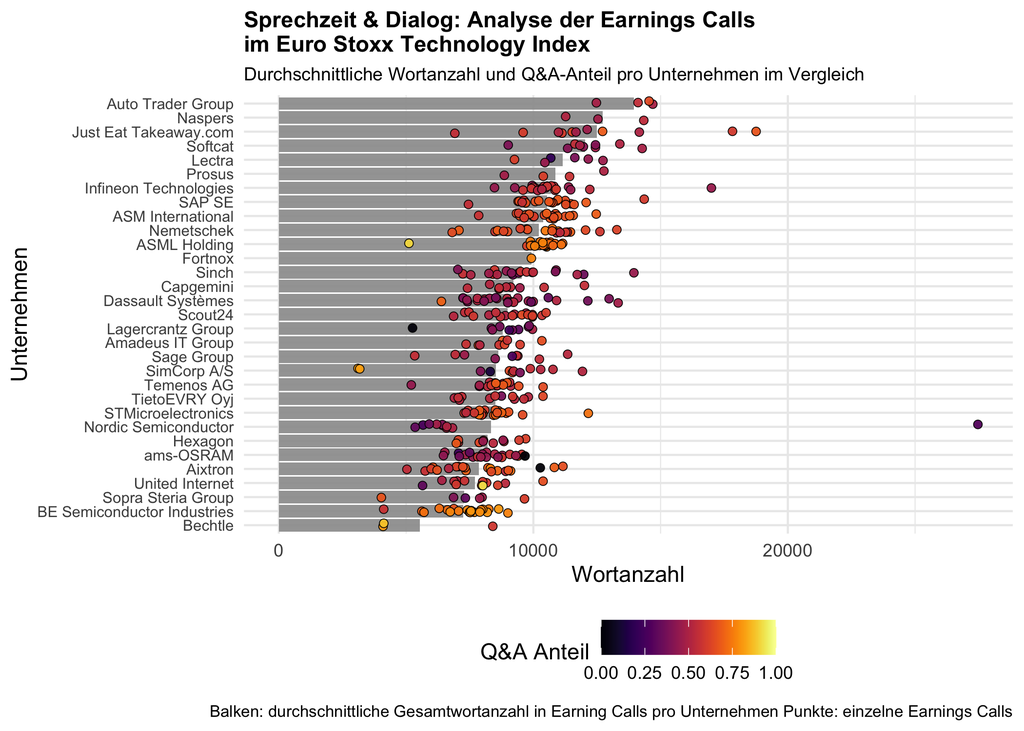

### Earnings Calls im Vergleich: Beschreibung der Grafik

Die dargestellte Grafik kombiniert ein Balkendiagramm mit einem Punktdiagramm, um sowohl die durchschnittliche Wortanzahl als auch den Q&A-Anteil innerhalb der Earnings Calls anschaulich zu visualisieren. Für jedes Unternehmen des Euro Stoxx Technology Index wird ein horizontaler Balken gezeigt, der die durchschnittliche Länge der Earnings Calls in Wörtern repräsentiert. Darüber hinaus sind einzelne Punkte eingetragen, die jeweils einen konkreten Earnings Call des Unternehmens darstellen. Diese sind auf der vertikalen Achse dem entsprechenden Unternehmen zugeordnet. Eine Farbskala macht dabei den Anteil des Q&A-Segments an der Gesamtlänge des jeweiligen Calls sichtbar. Dunkle Farbtöne – von Schwarz bis Violett – stehen für einen niedrigen Q&A-Anteil, während Orange- und Gelbtöne einen mittleren bis sehr hohen Anteil kennzeichnen.

**Variation im Q&A-Anteil**

Der Q&A-Anteil innerhalb der Calls schwankt stark: Manche enthalten keinerlei Fragerunde, während andere einen Anteil von bis zu 92,5% aufweisen. Die Mehrheit der Calls liegt jedoch bei einem Q&A-Anteil von etwa 60%. In der Grafik ist außerdem zu erkennen, dass einige Unternehmen durch eine deutlich größere Anzahl an dargestellten Punkten vertreten sind. Dies liegt daran, dass unvollständige oder fehlerhafte Datensätze bei der Auswertung ausgeschlossen wurden. So stehen für die Bechtle AG lediglich drei vollständige Earnings Calls zur Verfügung, während Dassault Systèmes SE mit 26 vollständigen Beobachtungen vertreten ist.

**Unterschiede im Kommunikationsverhalten**

Neben der Datenverfügbarkeit zeigen sich auch qualitative Unterschiede im Kommunikationsverhalten der Unternehmen. Einige tendieren dazu, eher wenige oder gar keine Fragen zuzulassen – dazu zählen etwa die ams-OSRAM AG, Dassault Systèmes SE und die Lagercrantz Group. Demgegenüber stehen Unternehmen wie BE Semiconductor Industries und ASML Holding, die durch besonders hohe Q&A-Anteile auffallen und damit einen dialogorientierteren Ansatz in ihren Earnings Calls verfolgen.

## Themenkategorien und Sentiment-Scores

Nachdem Sie nun die Earnings Conference Calls in R eingelesen und einen ersten Eindruck von deren Inhalt erhalten haben sollten Sie diese mit einem LLM (konkret mit Google Gemini) analysieren. Dafür sollten Sie einen Zero-Shot Prompt erstellen und mit Hilfe dieses Prompts die Aussage der Q&A Sektionen der Earnings Conference Calls analysieren.

9. Entwickeln Sie einen Zero-Shot Prompt für ein Large Language Model (LLM), der Earnings Conference Call Transcripts analysiert und strukturierte Sentiment-Bewertungen ausgibt. Bitte beachten Sie dabei folgende Punkte:

Zielkategorien:

- Unternehmensperformance (Finanzlage, Wachstumschancen, Unternehmensrisiken)
- Marktumfeld (Branche, Wettbewerb, externe Faktoren)

Output-Format:

- JSON-Struktur mit Sentiment-Scores von -1 (sehr negativ) bis +1 (sehr positiv)
- Keine zusätzlichen Erklärungen oder Markdown-Formatierung

Sie sollten in ihrem Prompt nach einem JSON Output verlangen (strukturiertes Format), welchen Sie mit dem Paket `jsonlite` gut in R verarbeiten können.

*Hinweis 1:* Im Anhang ist eine Erklärung für die Unterschiede zwischen einem Zero-Shot Prompt, einem One-Shot Prompt und einem Few-Shot Prompt

*Hinweis 2:* Wir haben Ihnen ein [Tutorial zusammengestellt](https://projektkurs-data-science-ulm2425.netlify.app/tutorials/zero-prompting), welches das Prompting an einem Beispiel zeigt.

Du bist ein erfahrener Finanzanalyst, der Earnings Call Q&A-Sektionen analysiert.

Deine Aufgabe: Analysiere die Aussagen im Text und bewerte sie hinsichtlich **Unternehmensperformance** und **Marktumfeld** – basierend auf Stimmung und Inhalt.

1. unternehmensperformance Bewerte Aussagen über:
- Umsatz, Margen, Kosten, Gewinnentwicklung
- Investitionen, Produktivität
- Tonlage des Managements, interne Risiken
2. marktumfeld Bewerte Aussagen über:
- Branchentrends, Nachfrageentwicklung
- Wettbewerbssituation
- Regulierung, Zinspolitik, makroökonomische Lage

Bewertungslogik: Verwende je Kategorie einen Score zwischen **-1.0 und +1.0**: - +1.0 = stark positiv  
- +0.5 = moderat positiv  
- 0.0 = neutral (nur bei echter Ausgewogenheit)  
- -0.5 = moderat negativ  
- -1.0 = stark negativ  
- NA = keine bewertbare Aussage vorhanden

**Wichtig:** Gib 0.0 **nur** bei wirklich neutralem Ton.  
Gib NA zurück, wenn **keine Information zur Bewertung** vorhanden ist.

konfidenz Bewerte deine eigene Sicherheit für das Gesamturteil auf einer Skala von **0.0 (völlig unsicher) bis 1.0 (sehr sicher)**.  
Beziehe dabei ein: - Klarheit und Konkretheit der Aussagen - Widersprüchlichkeit oder Uneindeutigkeit - Anzahl relevanter Hinweise im Text

10. Im nächsten Schritt sollten Sie sich in das Paket [`ellmer`](https://ellmer.tidyverse.org/) einarbeiten. Durch `ellmer` erhalten Sie Zugriff auf alle gängigen LLMs mittels R über einen API Zugang. Wir haben ihnen für dieses Projekt ein Google Konto pro Gruppe erstellt und den API Schlüssel für jede Gruppe in das dazugehörige Repo (Readme) gepushed.
- Lesen Sie sich in das [`ellmer`](https://ellmer.tidyverse.org/) Paket ein und wie Sie den API Schlüssel für Google Gemini in ihrer .Renviron Datei hinterlegen können
- Untersuchen Sie die unterschiedlichen Modelle, die Google zur Verfügung stellt und deren Ratelimits: https://ai.google.dev/gemini-api/docs/models?hl=de

Bitte beantworten Sie folgende Fragen:

- Was sind die Vorteile/Nachteile der einzelnen Google Modelle?
- Welches (kostenlose) Modell würden Sie für ihre aktuellen Analysen bevorzugt einsetzen? Begründen Sie!
- Welche Möglichkeiten haben Sie, nicht in die Ratelimits zu kommen?
- In `ellmer` können Sie mittels dem [`params()`](https://www.tidyverse.org/blog/2025/05/ellmer-0-2-0/#parameters) Parameter auch die Temperatur ihres Modells einstellen. Was ist mit der Temperatur gemeint und was sind die Vorteile/Nachteile einer niedrigen Temperatur?

### Modellauswahl für textbasierte Analysen mit der Google Gemini API

Die Google Gemini API stellt eine Vielzahl von Modellen zur Verfügung, die sich hinsichtlich ihrer Leistungsfähigkeit, Geschwindigkeit, Kostenstruktur und ihres Anwendungsspektrums unterscheiden. Für textbasierte Analyseaufgaben wie die Auswertung von Earnings Calls sind insbesondere die Modelle der Gemini-2.5- und 2.0-Reihe relevant. Da in diesem Kontext keine Audio- oder Sprachanalyse erforderlich ist, können Modelle mit Fokus auf diese Funktionen außer Acht gelassen werden.

**Gemini 2.5 Pro: Maximale Leistung für komplexe Aufgaben**

Das leistungsstärkste Modell innerhalb der Gemini-Familie ist Gemini 2.5 Pro. Es wurde für besonders komplexe Aufgaben entwickelt, die ein hohes Maß an Kontextverständnis und analytischem Denken erfordern. Dank seines großen Kontextfensters von über einer Million Token, der Fähigkeit zur Verarbeitung multimodaler Eingaben (wie Text, Bild, Audio, Video und PDF) sowie der Unterstützung strukturierter Ausgaben und Funktionsaufrufe eignet es sich hervorragend für anspruchsvolle Anwendungen. Zudem kann es Code ausführen und komplexe Dokumente effizient verarbeiten. Allerdings bringt diese hohe Leistungsfähigkeit auch Nachteile mit sich: Gemini 2.5 Pro ist kostenpflichtig, weist eine höhere Latenz auf und ist aufgrund seiner Rechenintensität weniger gut für schnelle, serielle Anfragen oder die Bearbeitung großer Datenmengen geeignet.

**Gemini 2.0 Flash: Effizienz und Analysegenauigkeit im Gleichgewicht**

Für solche Anforderungen bieten sich effizientere Modelle an. Besonders hervorzuheben ist hier Gemini 2.0 Flash. Dieses Modell überzeugt durch eine sehr gute Kombination aus Geschwindigkeit, Stabilität und Analyseleistung – bei gleichzeitig kostenloser Nutzungsmöglichkeit. Im direkten Vergleich zu Gemini 2.5 Flash zeigt es eine ähnliche Genauigkeit bei der Analyse umfangreicher Textdaten, reagiert jedoch schneller und eignet sich dadurch ideal für den Einsatz in Analyseprozessen, die auf Skalierbarkeit und Effizienz angewiesen sind. Auch bei der Arbeit mit Transkripten oder großen Textmengen bietet es eine hohe Zuverlässigkeit und Geschwindigkeit, ohne auf essenzielle Analysefunktionen zu verzichten.

**Weitere Modellvarianten**

Weitere Varianten wie Gemini 2.5 Flash Lite oder Gemini 2.0 Flash Lite sind noch stärker auf Effizienz bei hohem Anfragevolumen ausgelegt. Allerdings befindet sich das 2.5 Flash Lite-Modell derzeit in einer Vorschauphase und kann daher instabil oder eingeschränkt sein. Auch die Modelle Gemini TTS (Text-to-Speech) sind für textanalytische Anwendungen nicht relevant, da sie auf Sprachausgabe spezialisiert sind und geringere Tokenlimits aufweisen.

**Beachtung von Ratenlimits bei der API-Nutzung**

Ein zentrales Thema bei der Nutzung der Gemini API sind die sogenannten Ratenlimits, also Beschränkungen hinsichtlich der Anzahl an Anfragen pro Minute oder Tag sowie der verarbeiteten Tokens pro Minute. Diese Limits variieren je nach gewähltem Modell und Nutzungsstufe. Um diese Begrenzungen nicht zu überschreiten, empfiehlt es sich, parallele Anfragen zu vermeiden, zwischen einzelnen Requests gezielte Pausen einzubauen und umfangreiche Analysen in kleinere, nacheinander ausgeführte Abschnitte zu unterteilen.

**Temperatursteuerung zur Ergebnisoptimierung**

Ein weiterer wichtiger Aspekt ist die sogenannte Temperatur, ein Parameter, der über die Funktion params() im ellmer-Paket gesteuert werden kann. Die Temperatur beeinflusst, wie kreativ oder deterministisch das Modell auf Eingaben reagiert. Eine niedrige Temperatureinstellung (z. B. 0 bis 0.3) führt zu stabileren, konsistenteren und faktenorientierten Ergebnissen, was insbesondere für sachliche und reproduzierbare Analysen von Vorteil ist. Höhere Temperaturen hingegen erhöhen die Variabilität und Kreativität der Antworten, was in explorativen Kontexten wünschenswert sein kann, jedoch zu weniger verlässlichen Resultaten führen kann.

**Fazit: Gemini 2.0 Flash als optimale Wahl für Textanalysen**

Zusammenfassend lässt sich feststellen, dass das Modell Gemini 2.0 Flash derzeit die beste Wahl für textbasierte, präzise und ressourcenschonende Analysen darstellt. Es vereint eine hohe Geschwindigkeit mit solider Analysegenauigkeit, ist kostenfrei nutzbar und lässt sich problemlos in automatisierte Workflows integrieren. In Kombination mit einer bewussten Nutzung der API-Ressourcen und einer geeigneten Temperaturkonfiguration bietet es eine leistungsstarke und effiziente Grundlage für anspruchsvolle Textanalysen.

11. Nutzen Sie ihren in Aufgabe 9 erstellten Prompt mit dem `ellmer` Paket und ihrem Google API-Key um alle 431 Earnings Conference Call Transkripte zu analysieren. Nutzen Sie für ihre Analyse das Modell Google Gemini 2.0-flash oder Google Gemini 2.5-flash.

Speichern Sie die Ergebnisse ihrer Analyse in einem strukturierten Tibble ab. Anschließend sollten Sie den Datensatz auch unter `data/sentiment.Rds` abspeichern.

Stellen Sie ihre Ergebnisse in einer Tabelle dar und beschreiben diese kurz:

- Wie ist der Mittelwert, Standardabweichung und Median der Einschätzung bezüglich Unternehmensperformance und Marktumfeld in ihren Earnings Conference Calls?

*Hinweis 1:* Achten Sie darauf nicht bei jedem Knitten die Analyse neu zu starten, sondern setzen Sie den Chunk dieser Aufgabe auf `eval = FALSE` und lassen Sie die Analyse nur einmal durchlaufen und speichern Sie die Ergebnisse ab (und laden diese später um damit weiterarbeiten zu können)

*Hinweis 2:* Achten Sie auf ihre Ratelimits und beanspruchen Sie den API Zugriff nicht zu stark, z.B. durch den Einbau von “sleep”-Zeiten in ihrem Code

**Zusammenfassung der Sentiment-Analyse**<sup>1</sup>

Statistische Kennzahlen der Einschätzungen zu Unternehmensperformance und Marktumfeld

| Statistik | Unternehmensperformance | Marktumfeld |
| --- | --- | --- |
| Mittelwert | 0.406 | 0.176 |
| SD | 0.341 | 0.369 |
| Median | 0.500 | 0.200 |

<sup>1</sup> Daten basieren auf der Sentiment-Analyse der Q&A-Sektionen von 429 Earnings Conference Calls, bewertet mittels Google Gemini API.

### Analyseergebnisse der Sentiment-Auswertung

**Grundlage der Auswertung**

Für insgesamt 429 Earnings Calls wurden mithilfe eines systematischen Prompts maschinell Aussagen zur Unternehmensperformance und zum Marktumfeld ausgewertet. Jede Transkript-Antwort wurde mit drei numerischen Werten versehen:

- `unternehmensperformance`: Einschätzung der Stimmung und der Leistung des Unternehmens
- `marktstimmung`: Bewertung des externen Umfelds
- `konfidenz`: Einschätzung der Analyse-Zuverlässigkeit

Alle Werte reichen von –1.0 (sehr negativ) bis +1.0 (sehr positiv), wobei 0.0 für eine echte neutrale Einschätzung steht. NA wurde vergeben, wenn keine verwertbare Aussage gemacht wurde.

**Bewertung der Unternehmensperformance**

Der Mittelwert von 0.406 zeigt insgesamt eine moderat positive Einschätzung der Unternehmenslage durch das Management. Diese Einschätzung deutet darauf hin, dass viele Unternehmen ihre aktuelle finanzielle Situation, operative Entwicklung oder strategische Ausrichtung eher optimistisch bewerten. Die Standardabweichung von 0.341 signalisiert jedoch, dass es durchaus Unterschiede in der Einschätzung zwischen den Unternehmen gibt – während einige sich sehr positiv äußern, zeigen sich andere deutlich zurückhaltender. Der Median von 0.500 unterstreicht diesen Befund und legt nahe, dass die typische Einschätzung leicht bis klar positiv ist. Insgesamt sprechen diese Ergebnisse für eine tendenziell stabile bis optimistische Eigenwahrnehmung.

**Bewertung des Marktumfelds**

Anders stellt sich die Lage beim externen Marktumfeld dar. Hier liegt der Mittelwert lediglich bei 0.176, was auf eine insgesamt verhaltene bis leicht positive Stimmung schließen lässt. Die Einschätzungen sind damit spürbar zurückhaltender als jene zur Unternehmensperformance. Dies zeigt sich auch in der höheren Standardabweichung von 0.369, die auf eine größere Streuung und Uneinigkeit zwischen den Aussagen hinweist. Diese Differenzierung lässt sich wahrscheinlich durch Unterschiede in Branchenkonjunktur, makroökonomischen Entwicklungen oder geopolitischen Unsicherheiten erklären. Der Median von 0.200 bestätigt, dass viele Aussagen lediglich leicht positiv oder neutral ausfielen.

**Fazit**

Die Analyse zeigt eine deutliche Tendenz: Während Unternehmen ihre eigene Lage häufig optimistisch einschätzen, ist die Bewertung des externen Marktumfelds merklich vorsichtiger und von größerer Unsicherheit geprägt. Dieser Unterschied deutet darauf hin, dass Unternehmen intern auf stabile Prozesse, gute Ergebnisse oder strategischen Fortschritt blicken, jedoch gleichzeitig die äußeren Rahmenbedingungen – etwa durch Inflation, geopolitische Spannungen, regulatorische Eingriffe oder Nachfragerisiken – als herausfordernder empfinden.

Sie haben in der vorherigen Aufgabe die Stimmung bezüglich der Kategorien Unternehmensperformance und Marktperformance in den Earnings Conference Calls bestimmt. Eine Frage wäre, ob sich diese Stimmung über die Zeit hinweg verändert hat. In der folgenden Aufgabe sollen Sie sich die durchschnittliche Stimmung in diesen zwei Kategorien für die einzelnen Jahre in ihrem Datensatz näher anschauen.

12. Erstellen Sie eine geeignete Grafik um die Stimmung *aller Earnings Conference Calls eines Jahres* zu visualisieren. Tragen Sie separat die Stimmung bezüglich Unternehmensperformance und Marktumfeld ab.

Beschreiben Sie ihre Grafik.

Interpretieren Sie diese Grafik, insbesondere im Hinblick auf die gesamtwirtschaftlichen Ereignisse der letzten fünf Jahre. Hätten Sie die Ergebnisse in dieser Art erwartet?

*Hinweis:* Sie sollten sich hier eine sinnvolle Grafik überlegen, welche die Stimmungslage über die Zeit gut darstellt.

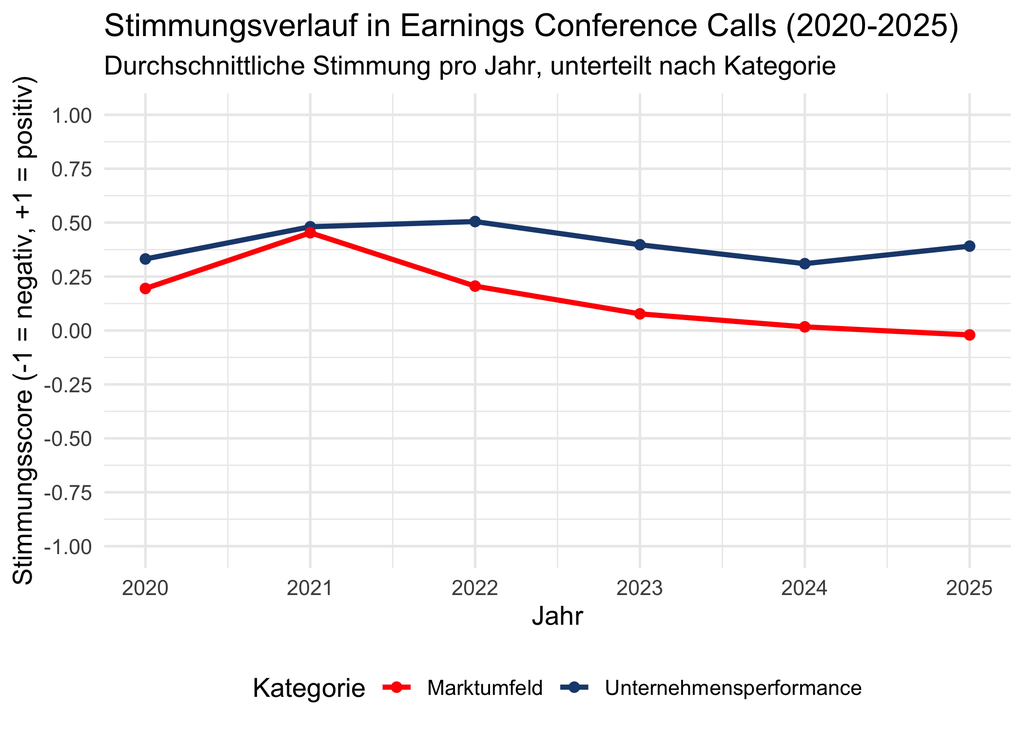

### Zeitverlauf der Unternehmens- und Markteinschätzungen in Earnings Calls (2020–2025)

**Beschreibung der Grafik**

Die Grafik zeigt den durchschnittlichen Sentiment-Score in Earnings Conference Calls für die Jahre 2020 bis 2025, getrennt nach den Kategorien „Unternehmensperformance” (blaue Linie) und „Marktumfeld” (rote Linie). Die vertikale Achse zeigt den Sentiment-Score auf einer Skala von −1 (sehr negativ) bis +1 (sehr positiv), die horizontale Achse bildet den Zeitverlauf in Jahren ab. Jeder Datenpunkt stellt den Mittelwert aller Transkripte pro Jahr und Kategorie dar.

Insgesamt fällt auf, dass die Einschätzungen zur Unternehmensperformance stets über jenen zum Marktumfeld liegen. Beide Kategorien zeigen jedoch keinen einheitlichen Trend, sondern einen teils gegenläufigen Verlauf. Besonders deutlich wird dies ab 2022, wo sich die Stimmung zur Unternehmensperformance auf hohem Niveau stabilisiert, während das Marktsentiment deutlich abfällt – und 2025 sogar leicht ins Negative dreht.

**Interpretation der Grafik**

*2020: Verhaltener Optimismus trotz Krisenlage*

Im Jahr 2020 lag der durchschnittliche Stimmungswert zur Unternehmensperformance bei 0.33, während das Marktumfeld mit 0.19 etwas zurückhaltender bewertet wurde. Trotz der massiven globalen Verwerfungen durch die COVID-19-Pandemie – etwa Lockdowns, unterbrochene Lieferketten und Nachfrageeinbrüche – blieben die Aussagen der Unternehmen insgesamt überraschend positiv. Dies deutet auf einen vorsichtigen Optimismus hin, insbesondere bei Unternehmen, die sich frühzeitig an digitale Arbeits- und Geschäftsmodelle angepasst oder von der beschleunigten Digitalisierung profitiert haben. Die vergleichsweise stabile Einschätzung der Unternehmenslage zeigt, dass viele Firmen 2020 resilient reagierten – im Gegensatz zur allgemeinen wirtschaftlichen Unsicherheit.

*2022: Divergenz zwischen Unternehmenssicht und externem Umfeld*

2022 setzte sich die positive Entwicklung aus Sicht der Unternehmensperformance fort und erreichte mit 0.51 sogar den höchsten Wert der gesamten Serie. Gleichzeitig fiel das Marktsentiment jedoch deutlich auf 0.21 zurück. Diese Kluft lässt auf eine zunehmende Diskrepanz zwischen interner Lageeinschätzung und externer Unsicherheit schließen. Während Unternehmen operativ oft weiterhin gut aufgestellt waren, sorgten der Ukrainekrieg, hohe Energiepreise, unterbrochene Lieferketten und eine unsichere Geldpolitik für ein zunehmend skeptisches Bild des Marktumfelds. Das Vertrauen in die eigene Anpassungsfähigkeit blieb hoch – die gesamtwirtschaftliche Lage hingegen wurde kritischer gesehen.

*2023: Marktskepsis nimmt weiter zu*

Im Jahr 2023 erreichte das Marktsentiment mit 0.08 einen neuen Tiefpunkt. Gleichzeitig sank die Einschätzung zur Unternehmensperformance leicht auf 0.40, blieb jedoch weiterhin deutlich im positiven Bereich. Die Differenz zwischen den beiden Kategorien bleibt signifikant. Die Ursachen für die zunehmend pessimistische Markteinschätzung dürften in anhaltender Inflation, zunehmender Rezessionsangst sowie geopolitischer Instabilität liegen. Zudem wirkte sich eine restriktivere Geldpolitik – etwa durch Zinsanhebungen großer Zentralbanken – dämpfend auf Investitionsbereitschaft und Nachfrageerwartungen aus. Unternehmen äußerten sich zwar noch immer zuversichtlich, schienen aber vermehrt auf Unsicherheiten zu reagieren.

*2024: Stimmungstief am Markt, Rückgang auch bei Unternehmen*

2024 markiert den bisherigen Tiefpunkt in der Stimmung: Das Marktsentiment sank auf 0.02, während auch der Score zur Unternehmensperformance mit 0.31 rückläufig war. Dies lässt auf eine spürbare Zurückhaltung in der Kommunikation schließen – sowohl was unternehmensinterne Perspektiven als auch makroökonomische Einschätzungen betrifft. Mögliche Ursachen sind eine konjunkturelle Abkühlung, anhaltend hohe Kostenbelastungen (z.B. Energie, Rohstoffe), wachsende Unsicherheiten in Handelsbeziehungen sowie die Sorge vor einer schwächelnden globalen Nachfrage. Offenbar wuchs die Vorsicht bei Investoren und Unternehmen gleichermaßen – ein Stimmungsbild, das auch in rückläufigen Aktienmärkten und schwächerem Wachstum reflektiert wurde.

*2025: Pessimismus im Marktumfeld – Trendwende bei Unternehmen?*

Im Jahr 2025 rutschte das Marktsentiment erstmals in den negativen Bereich und lag bei –0.02. Das ist ein klares Signal für zunehmenden Pessimismus im Hinblick auf das wirtschaftliche und politische Umfeld. Besonders geopolitische Risiken – etwa eine protektionistischere US-Wirtschaftspolitik unter einer möglichen zweiten Trump-Administration – könnten zur Unsicherheit beigetragen haben. Gleichzeitig erholte sich die Unternehmensperformance auf 0.39. Dies könnte auf erfolgreiche Strategien zur Effizienzsteigerung, Diversifikation oder technologische Innovationen hinweisen. Möglicherweise setzen Unternehmen zunehmend auf Resilienzstrategien und Kostenkontrolle, um sich unabhängiger von externen Unsicherheiten zu machen – ein Hoffnungsschimmer inmitten globaler Volatilität.

**Fazit**

Die Ergebnisse zeigen deutlich, dass Unternehmen ihre eigene Lage durchweg positiver einschätzen als das allgemeine Marktumfeld. Insbesondere seit 2022 nimmt die Diskrepanz zwischen den beiden Einschätzungen zu. Diese Entwicklung ist nachvollziehbar: Viele der analysierten Unternehmen – überwiegend aus dem europäischen Technologiesektor – verfügen über robuste Geschäftsmodelle und starke Marktpositionen. Gleichzeitig nehmen externe Unsicherheiten wie geopolitische Risiken, Zinswenden, Zölle, regulatorische Eingriffe oder eine schwache globale Nachfrage spürbar zu und schlagen sich im Marktsentiment nieder.

# Eventstudie

Um zu evaluieren, ob die Earnings Conference Calls tatsächlich einen Einfluss auf die Aktienkurse der einzelnen Unternehmen hatten können Sie eine sogenannte Eventstudie durchführen, welche Sie bereits in Aufgabe 1 kennen gelernt haben. Bei einer Eventstudie betrachten Sie nur die Zeit (bei uns die Tage) unmittelbar vor oder nach einem Event. In diesem Projekt ist ein Event ein Earnings Conference Call des jeweiligen Unternehmens. Sie sollen in diesem Projekt herausfinden, wie sich über alle Unternehmen hinweg die Earnings Conference Calls auf die Aktienrenditen auswirken.

13. Verbinden Sie den Datensatz über die *Stimmung der Earnings Conference Calls (sentiment.Rds)* zu den einzelnen Unternehmen mit den *abnormalen Renditen* und speichern diesen Datensatz als `gesamtdatensatz` in R ab. Sie können das RIC-Kürzel und Datum für den Join verwenden. Sollte der Earnings Conference Call an keinem Handelstag stattgefunden haben, so joinen Sie bitte mit dem darauffolgenden Handelstag.
- Für die Tage an denen ein Earnings Conference Call stattgefunden hat sollten Sie eine Variable `event` generieren, welche an dem Tag des Calls gleich 0 ist.
- Für die Tage vor dem Earnings Conference Call (Event) sollte die Variable `event` rückwärts zählen (bis zu -5). Für alle Tage nach dem Event sollte die Variable `event` fortgeführt werden (bis +5).
- Erstellen Sie eine Variable `ar_505`, welche die *abnormalen Rendite* von Tag -5 bis +5 **fortlaufend** aufsummiert
- Erstellen Sie eine Variable `car_101`, welche die kumulierte abnormale Rendite im Zeitraum -1 bis +1 um das Event beinhaltet
- Erstellen Sie weiterhin diese sechs neuen Variablen:
  - `negativ_firm` = Wenn die Unternehmensperformance als negativ eingeschätzt wird
  - `neutral_firm` = Wenn die Unternehmensperformance als neutral eingeschätzt wird
  - `positiv_firm` = Wenn die Unternehmensperformance als positiv eingeschätzt wird
  - `negativ_market` = Wenn die Marktperformance als negativ eingeschätzt wird
  - `neutral_market` = Wenn die Marktperformance als neutral eingeschätzt wird
  - `positiv_market` = Wenn die Marktperformance als positiv eingeschätzt wird
- Erstellen Sie Dummy Variablen, die 1 sind für ein bestimmtes Jahr. Bspw. eine Dummyvariable die 2020 heißt und für alle Beobachtungen im Jahr 2020 sollte diese Variable 1 sein, 0 sonst. Tun Sie dies für alle Jahre in ihrem Datensatz

*Hinweis:* Die Funktion cumsum() könnte für diese Aufgabe hilfreich sein

14. Erstellen Sie je ein Liniendiagramm für die von ihnen betrachteten Unternehmen: Eines für die Stimmung bezüglich der Unternehmensperformance und eines bezüglich der Marktperformance.

Sie sollten in ihren Grafiken die kumulierten Renditen im Zeitraum [-5,5] Tage um einen Earnings Conference Call darstellen. - Die Variable “Event” sollte die Tage vor und nach dem Earnings Conference Call enthalten ([-5,5]) und auf der x-Achse dargestellt werden - Die Variable `ar_505` sollte die durchschnittliche kumulierte abnormale Rendite für den jeweiligen Tag auf der y-Achse abtragen (für alle Unternehmen in ihrem Datensatz) - In jeder Grafik sollten Sie eine extra Linie zeichnen für Earnings Conference Calls mit einer positiven/negativen und neutralen Stimmung und deren Einfluss auf den Aktienmarkt

Beschreiben und interpretieren Sie ihre Grafik. Gehen Sie hierbei insbesondere darauf ein, welche Erwartungen Sie auf der Basis ihrer Lektüre aus Aufgabe 1 hatten und in wie weit diese Erwartungen sich erfüllt haben.

*Hinweis:* In diesen Grafiken stellen Sie nicht jedes Event (d.h. die Auswirkungen eines jeden Earnings Conference Calls) einzeln dar, sondern gesamt für alle Earnings Conference Calls.

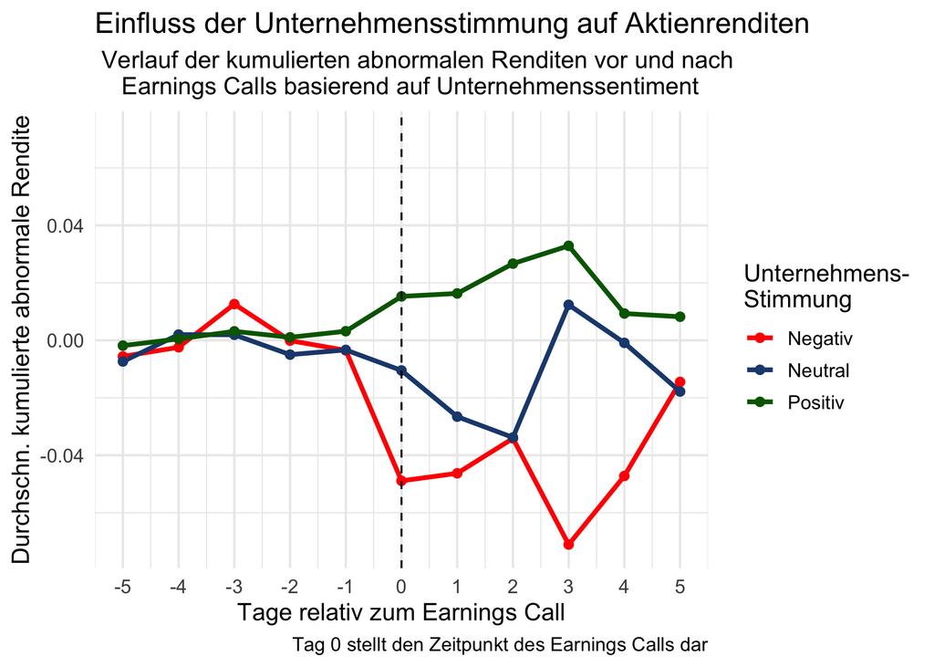

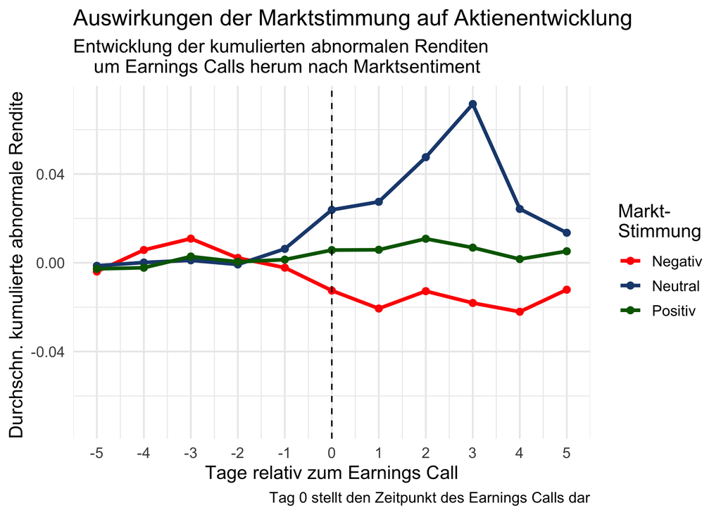

### Einfluss von Earnings Calls auf kumulierte abnormale Renditen: Analyse nach Unternehmens- und Marktstimmung

**Beschreibung der Grafiken**

Die beiden dargestellten Liniendiagramme zeigen den Verlauf der durchschnittlichen kumulierten abnormalen Renditen im Zeitraum von fünf Tagen vor bis fünf Tage nach einem Earnings Conference Call. Die horizontale Achse bildet die Tage relativ zum Ereignis ab, wobei der Zeitpunkt 0 den Tag des Calls markiert. Die vertikale Achse zeigt die kumulierte Abweichung der tatsächlichen Aktienrenditen vom erwarteten Verlauf, der auf einer Marktmodell-Prognose basiert.

Im ersten Diagramm wird die kumulierte Rendite in Abhängigkeit zur Unternehmensstimmung, im zweiten Diagramm entsprechend in Abhängigkeit zur Marktstimmung dargestellt. Die Segmentierung erfolgt jeweils in die drei Gruppen positiv, neutral und negativ, die sich nach den durch das LLM geschätzten Sentiment-Werten richten. Für jede dieser Kategorien wurde die durchschnittliche kumulierte Rendite über alle relevanten Ereignisse hinweg berechnet.

**Interpretation der Ergebnisse - Unternehmensstimmung**

Das Liniendiagramm zur kumulierten abnormalen Rendite in Abhängigkeit von der Unternehmensstimmung zeigt deutliche Unterschiede im Kursverlauf vor und nach einem Earnings Conference Call.

*Deutlicher Kursrückgang bei negativem Sentiment*

Bei negativem Sentiment ist ein klarer Abwärtstrend zu erkennen. Bereits vor dem Ereignis liegen die Renditen im negativen Bereich, doch am Tag des Calls und in den darauffolgenden Tagen verschärfen sich die Verluste deutlich. Die Kurve fällt stark ab, was auf eine unmittelbare und substanzielle negative Marktreaktion hindeutet. Erst gegen Ende des Beobachtungszeitraums ist eine leichte Gegenbewegung sichtbar, die jedoch nicht ausreicht, um die vorherigen Verluste auszugleichen. Dieses Muster entspricht den klassischen Erwartungen der Kapitalmarktforschung: Negativ wahrgenommene Aussagen des Managements führen zu Kursabschlägen, da der Markt die neuen Informationen schnell und effizient einpreist.

*Unerwartete Verluste auch bei neutraler Unternehmensstimmung*

Der Verlauf bei neutralem Sentiment überrascht hingegen. Die Kurve zeigt auch hier durchgehend negative Werte, mit einer deutlichen Verschlechterung ab dem Tag des Calls. Anstatt einer stabilen oder seitwärts gerichteten Bewegung, wie man sie bei neutraler Tonalität erwarten würde, setzt sich ein klarer Abwärtstrend fort. Dies könnte auf eine systematische Fehleinschätzung der tatsächlichen Aussageinhalte durch das Sentiment-Modell hindeuten oder darauf, dass der Markt in einem insgesamt pessimistischen Umfeld bereits neutrale Aussagen als negativ interpretiert. Auch methodische Aspekte, wie eine geringe Anzahl an Beobachtungen oder die Verzerrung durch einzelne extreme Ereignisse, könnten eine Rolle spielen.

*Moderate, aber stetige Kursgewinne bei positivem Sentiment*

Bei positivem Sentiment verläuft die Entwicklung hingegen weitgehend im Einklang mit theoretischen Erwartungen. Die kumulierten Renditen bewegen sich durchgängig im positiven Bereich und steigen rund um den Earnings Call kontinuierlich an. Die Zuwächse sind zwar nicht explosionsartig, zeigen aber eine klare Tendenz nach oben, was auf eine konstruktive Marktaufnahme positiver Aussagen hindeutet. Auffällig ist, dass ein Teil der Kursgewinne bereits vor dem Call einsetzt, was dafür sprechen könnte, dass positive Erwartungen teilweise vorweggenommen wurden. Dies passt zur Hypothese, dass der Markt bereits im Vorfeld antizipiert, welche Richtung der Call nehmen wird – ein typisches „buy the rumor“-Phänomen.

**Interpretation der Ergebnisse - Marktstimmung**

*Verhaltener negativer Effekt bei negativem Marktsentiment*

Das Liniendiagramm zeigt bei negativem Sentiment der Marktstimmung einen leichten Anstieg der kumulierten abnormalen Renditen in den Tagen vor dem Earnings Call, gefolgt von einem deutlichen Rückgang am Tag des Events. Dieser Kursrückgang verstärkt sich am Folgetag, bevor sich die Renditen in den darauffolgenden Tagen teilweise erholen, jedoch weiterhin leicht negativ bleiben. Insgesamt fällt die negative Marktreaktion damit zwar auf, ist jedoch weniger ausgeprägt als bei der firmenspezifischen Stimmung. Dies lässt darauf schließen, dass Anleger stärker auf unternehmensbezogene Informationen reagieren als auf allgemeine Markteinschätzungen.

*Überraschend starke positive Reaktion auf neutrale Marktstimmung*

Bei neutraler Marktstimmung fällt der Verlauf überraschend positiv aus. Ab dem Tag des Calls steigen die kumulierten abnormalen Renditen deutlich an und erreichen einige Tage später ein deutliches Hoch. Erst in der späten Phase flacht die positive Entwicklung etwas ab, bleibt aber weiterhin auf einem positiven Niveau. Dieses Ergebnis widerspricht der Erwartung, dass neutrale Einschätzungen kaum Wirkung zeigen. Mögliche Erklärungen hierfür sind Klassifikationsfehler, bei denen vermeintlich neutrale Aussagen tatsächlich positive Inhalte transportierten, oder dass in einem schwachen oder unsicheren Marktumfeld neutrale Statements als beruhigend und stabilisierend wahrgenommen wurden. Zudem ist das Ergebnis vermutlich aufgrund von zu wenigen Beobachtungen nicht so aussagekräftig.

*Stabiler Anstieg bei positivem Marktsentiment*

Positives Sentiment in der Marktstimmung zeigt einen kontinuierlichen, wenn auch moderaten Anstieg der Renditen über den gesamten Zeitraum. Die positiven Effekte sind stabil, jedoch weniger dynamisch als bei neutraler Stimmung. Diese Entwicklung entspricht den Erwartungen, dass positive makroökonomische Signale den Aktienmarkt unterstützen, jedoch meist mit geringerer Intensität als firmenspezifische Nachrichten wirken.

**Methodische Einordnung**

Die vorliegende Analyse nutzt die Eventstudien-Methodik nach Huntington und Klein, um die kausalen Effekte des Earnings Calls auf die Aktienrenditen zu untersuchen.

Die Ergebnisse zeigen jedoch, dass insbesondere die Reaktionen auf neutrale Stimmungen teilweise überraschend stark ausfallen und teilweise nicht den theoretischen Erwartungen entsprechen. Dies weist darauf hin, dass die Klassifikation der Stimmungen nicht immer eindeutig ist und insbesondere bei neutralen Aussagen eine Über- oder Fehlinterpretation möglich sein könnte. Auch eine geringe Datenbasis oder Ausreißer können die Mittelwerte verzerren.

Darüber hinaus legen die differenzierten Reaktionen zwischen Unternehmens- und Marktstimmung nahe, dass Investoren stärker auf firmenspezifische Informationen reagieren als auf allgemeine Markteinschätzungen. Die moderaten Reaktionen auf positive Signale stimmen mit dem Muster erwartungskonformer Marktreaktionen überein, bei denen positive Nachrichten oft bereits im Vorfeld antizipiert werden.

Die Resultate sollten mit Vorsicht interpretiert und idealerweise durch weiterführende Analysen und Robustheitstests ergänzt werden, um Verzerrungen zu minimieren und die kausale Wirkung der Earnings Calls besser zu isolieren.

**Fazit**

Die Analyse bestätigt, dass Unternehmensstimmung bei Earnings Calls starken Einfluss auf Aktienkurse hat: Negative Aussagen führen zu klaren Kursverlusten, positive zu moderaten Gewinnen, die teilweise vorab erwartet werden. Überraschend fallen neutral eingestufte Unternehmensstimmungen überwiegend negativ aus, was auf Klassifikationsprobleme oder eine zu geringe Anzahl an Beobachtungen hindeutet.

Bei der Marktstimmung sind die Effekte weniger ausgeprägt, wobei neutrale Bewertungen sogar positive Kursreaktionen zeigen – vermutlich wegen Klassifikationsfehlern, zu wenigen Beobachtungen oder beruhigender Wirkung in unsicheren Zeiten. Positive makroökonomische Signale zeigen moderate, stabile Kursgewinne.

Insgesamt unterstreichen die Ergebnisse die Bedeutung firmenspezifischer Informationen und weisen auf methodische Grenzen bei der Sentiment-Analyse hin, insbesondere bei neutralen Bewertungen.

# Regressionen

Sie haben bisher den Einfluss der Earnings Conference Calls auf die Aktienrendite der größten europäischen Unternehmen im Technologie-Sektor visuell betrachtet. Im letzten Abschnitt dieser Projektarbeit analysieren Sie ihre Daten mittels linearer Regressionen.

15. In dieser Aufgabe sollten Sie zwei Regressionen erstellen:

Regressieren Sie die kumulierten abnormalen Renditen um das Event `car_101` auf die Dummyvariablen

- `negativ_firm` und `negativ_market` in der ersten Regression und
- `positiv_firm` und `positiv_market` in der zweiten Regression.

Diese Dummyvariablen geben die Stimmung in den Earnings-Conference Calls wieder.

Beschreibung und interpretieren Sie ihre Regressionsergebnisse und gehen Sie dabei auch auf folgende Fragen ein:

- Was ist die Vergleichsgruppe in den beiden Regressionen?
- Was sind die Voraussetzungen für eine kausale Interpretation der Koeffizienten. Sind diese ihrer Meinung nach gegeben?

**Regression der kumulierten abnormalen Renditen**

Stimmung in Earnings Conference Calls

|  | Negative Stimmung | Positive Stimmung |
| --- | --- | --- |
| (Konstante) | 0.014** | -0.026* |
|  | (0.005) | (0.010) |
| Negative Stimmung (Firma) | -0.045* |  |
|  | (0.018) |  |
| Negative Stimmung (Markt) | -0.014 |  |
|  | (0.014) |  |
| Positive Stimmung (Firma) |  | 0.053*** |
|  |  | (0.013) |
| Positive Stimmung (Markt) |  | -0.019* |
|  |  | (0.010) |
| R² | 0.036 | 0.041 |
| Adj. R² | 0.031 | 0.037 |
| F-Statistik | 7.43 (df = 2, 396) | 8.55 (df = 2, 396) |
| AIC | -808.23 | -810.40 |
| BIC | -792.27 | -794.44 |
| Beobachtungen | 399 | 399 |

* p < 0.05, ** p < 0.01, *** p < 0.001

### Einfluss der Stimmung in Earnings Calls auf Aktienrenditen

**Beschreibung der Regressionsmodelle**

Die beiden Regressionsmodelle untersuchen den Zusammenhang zwischen der Tonalität in Earnings Conference Calls und den kumulierten abnormalen Renditen im Zeitraum von einem Tag vor bis einem Tag nach dem Ereignis (CAR_101). Dabei wurden getrennt nach negativer und positiver Stimmung jeweils zwei Dummyvariablen berücksichtigt: eine für die firmenspezifische Stimmung (z.B. negative_firm) und eine für die marktorientierte Stimmung (z.B. negative_market). Die Regressionen wurden auf Basis von jeweils 399 Beobachtungen geschätzt.

*Ergebnisse des ersten Modells: Negative Stimmung*

Im ersten Modell zeigt sich ein signifikant negativer Effekt negativ wahrgenommener Unternehmensstatements: Diese sind im Durchschnitt mit kumulierten abnormalen Renditen von 4,5 Prozentpunkten (p < 0,05) weniger assoziiert. Dieser Effekt ist statistisch signifikant und unterstreicht die Bedeutung der Unternehmenskommunikation für Investitionsentscheidungen. Eine negativ wahrgenommene Marktsituation hat hingegen keinen signifikanten Einfluss auf die Rendite (β = −0,014, n. s.), was darauf hindeutet, dass der Markt firmenspezifischen Aussagen mehr Gewicht beimisst als allgemeinen makroökonomischen Einschätzungen.

*Ergebnisse des zweiten Modells: Positive Stimmung*

Im zweiten Modell zeigen sich spiegelbildliche Effekte. Positive Aussagen zur Unternehmenslage sind im Durchschnitt mit einer höheren Rendite um 5,3 Prozentpunkte assoziiert (p < 0,001), was einen signifikanten und ökonomisch relevanten Effekt darstellt. Ein positives Marktsentiment ist hingegen mit einer leichten negativen Veränderung der Rendite um 1,9 Prozentpunkte (p < 0,05) verbunden. Diese möglicherweise kontraintuitive Reaktion könnte darauf hindeuten, dass der Markt derartige Aussagen bereits eingepreist oder als überzogen bewertet hat.

**Vergleichsgruppe in den Modellen**

In beiden Regressionsmodellen dient die Gruppe mit neutralem Sentiment – also Beobachtungen ohne ausgeprägt positive oder negative Stimmung – als Referenzgruppe. Die Regressionskoeffizienten geben daher die durchschnittliche Abweichung der Rendite im Vergleich zu dieser neutralen Gruppe an. Die Interpretation der Effekte ist somit ausschließlich relativ zur neutralen Referenz möglich.

Da bei Aufgabe 14 die Kurvenverläufe für neutrale Earnings Calls – insbesondere in Bezug auf die Marktstimmung – unerwartet ausfielen und diese Gruppe zudem weniger Beobachtungen sowie potenzielle Klassifikationsfehler aufweist, sollten die geschätzten Koeffizienten mit entsprechender Vorsicht interpretiert werden.

Dadurch, dass die Kurve der neutralen Stimmung im Marktumfeld über dem Verlauf der positiven und negativen Stimmung liegt, ist es folgerichtig, dass sowohl für positive als auch für negative Stimmung negative Regressionskoeffizienten geschätzt wurden. Die Koeffizienten drücken lediglich die durchschnittliche Abweichung zur Referenzgruppe aus – und wenn diese überdurchschnittlich hohe Werte aufweist, erscheinen selbst leicht positive Entwicklungen in den anderen Gruppen im Vergleich dazu als relativ negativ.

**Voraussetzungen für eine kausale Interpretation**

Für eine kausale Interpretation der geschätzten Regressionskoeffizienten müssen mehrere Voraussetzungen erfüllt sein. Zunächst darf es keine simultan auftretenden Ereignisse geben, die die Rendite der Aktien unabhängig vom Earnings Call beeinflussen könnten.

Ein wesentlicher Vorteil der vorliegenden Analyse ist die Verwendung abnormaler Renditen. Diese basieren auf der Differenz zwischen der tatsächlichen und einer erwarteten Rendite, meist auf Grundlage eines Marktmodells. Dadurch werden systematische Markteinflüsse (z.B. allgemeine Kursschwankungen) bereits herausgerechnet, was die Interpretation der Effekte erheblich verbessert. Allerdings ist zu beachten, dass es unter Umständen nicht ausreicht, lediglich den Marktindex als Benchmark heranzuziehen. Denkbar ist, dass das Marktmodell nicht adäquat für die spezifische erwartete Performance einzelner Aktien kontrolliert, insbesondere wenn diese systematisch anders auf Marktbewegungen reagieren oder unternehmensindividuelle Trends aufweisen. Eine alternative Herangehensweise wäre daher, die durchschnittliche Performance der jeweiligen Aktie in einem ereignisfreien Zeitraum als Basis für die erwartete Rendite heranzuziehen. Dies könnte zu einer realistischeren Einschätzung der abnormalen Rendite führen, insbesondere wenn das Marktmodell verzerrt ist oder strukturelle Unterschiede zwischen den Unternehmen bestehen.

Ein Problem ist das Fehlen eines kontrafaktischen Verlaufs, also der Frage, wie sich die Rendite entwickelt hätte, wenn kein Earnings Call stattgefunden hätte oder dieser neutral gewesen wäre. Huntington-Klein (2021) unterscheidet drei Strategien zur Annäherung an dieses Problem: das Ignorieren eines Trends (geeignet bei sehr kurzen Zeitfenstern wie CAR_101), die Extrapolation aus Vorperioden sowie die Prognose mittels risikoadjustierter Modelle. Letztere Strategie – die auch hier angewandt wurde – erhöht die Robustheit der Schätzung, ist jedoch nicht völlig frei von Verzerrungsgefahren durch unbeobachtete Störfaktoren.

Ein weiteres Problem ist das Risiko eines Omitted-Variable-Bias: Die Modelle kontrollieren nicht für weitere potenziell relevante Einflussgrößen wie Unternehmensgröße, Volatilität, Sektortrends oder aktuelle wirtschaftspolitische Rahmenbedingungen. Auch strukturelle Annahmen der OLS-Schätzung – etwa Linearität, Homoskedastizität und Normalverteilung der Residuen – wurden nicht explizit überprüft. Schließlich sind die erklärten Varianzanteile mit R²-Werten von lediglich 0,036 bzw. 0,041 sehr gering, was die Aussagekraft der Modelle einschränkt.

In Summe sprechen diese Punkte dafür, die Ergebnisse vorsichtig und primär als deskriptive Zusammenhänge zu interpretieren. Für belastbare kausale Schlüsse wären weiterführende methodische Schritte erforderlich, etwa die Einbeziehung zusätzlicher Kontrollvariablen, die Prüfung auf unbeobachtete Heterogenität oder der Einsatz quasi-experimenteller Designs (z.B. Difference-in-Differences).

**Fazit**

Die Ergebnisse der Regressionsanalysen zeigen, dass die Stimmung in Earnings Conference Calls mit kurzfristigen Renditeveränderungen zusammenhängt. Positive Aussagen zur Unternehmenslage stehen im Durchschnitt mit Renditeanstiegen in Verbindung, negative Aussagen mit Kursverlusten – jeweils relativ zur neutralen Vergleichsgruppe.

Für Marktsentiments ergibt sich ein uneinheitliches Bild: Negative Einschätzungen zeigen keinen signifikanten Zusammenhang, während positive Marktaussagen tendenziell mit leicht negativen Renditen assoziiert sind.

Insgesamt deuten die Befunde darauf hin, dass Investoren nicht nur auf inhaltliche Informationen reagieren, sondern auch auf die Tonalität der Kommunikation – wobei die Interpretation stark vom Kontext abhängt.

16. In ihrer deskriptiven Analyse haben Sie bereits gesehen, dass die Unternehmen, die Sie in diesem Projekt betrachten, alle unterschiedlich groß sind. Weiterhin haben Sie gesehen, dass es ein unterschiedliches Stimmungsbild in den Calls über die einzelnen Jahre hinweg gibt. Dafür möchten Sie in ihren Regressionen nun kontrollieren.
    1. Regressieren Sie die `car_101` auf die Variablen *negativ_firm* und *negativ_market* und kontrollieren Sie auf die Größe des jeweiligen Unternehmens, indem Sie die Variable *Total_Assets* in ihre Regression aufnehmen
    2. Fügen Sie in einer zweiten Analyse zusätzlich zu den Variablen aus der 1. Regression auch noch Dummyvariablen für die Jahre in dem das Event stattgefunden hat ihrer Regression hinzu.
    3. Führen Sie die Regressionen aus 1. und 2. auch für die Variablen *positiv_firm* und *positiv_market* anstatt *negativ_firm* und *negativ_market* durch, sodass Sie am Ende 4 Regressionen haben

Beschreiben und interpretieren Sie ihre Ergebnisse im Hinblick auf die Größe der Koeffizienten und deren Signifikanz. Gehen Sie insbesondere auf folgende Fragen ein:

- Warum sollte ihre Regression nicht fünf Dummyvariablen, je eine für jedes Jahr, sondern nur vier beinhalten?
- Verändert sich durch die Dummyvariablen der Koeffizient von *negativ_firm* und *negativ_market* bzw. *positiv_firm* und *positiv_market*?
- Hätten Sie eine Veränderung des Koeffizienten von *negativ_firm*, *negativ_market*, *positiv_firm* oder *positiv_market* erwartet? Begründen Sie ihre Antwort mit ihren deskriptiven Analysen.

**Regression der kumulierten abnormalen Renditen**

Einfluss von Stimmung, Unternehmensgröße und Jahr auf die Marktreaktion

|  | Negativ (ohne Jahr) | Negativ (mit Jahr) | Positiv (ohne Jahr) | Positiv (mit Jahr) |
| --- | --- | --- | --- | --- |
| (Konstante) | 0.013* | 0.025* | -0.029** | -0.013 |
|  | (0.006) | (0.011) | (0.011) | (0.015) |
| Negative Stimmung (Firma) | -0.055** | -0.055** |  |  |
|  | (0.019) | (0.019) |  |  |
| Negative Stimmung (Markt) | -0.013 | -0.013 |  |  |
|  | (0.014) | (0.015) |  |  |
| Unternehmensgröße (Total Assets) | -0.000 | -0.000 | -0.000 | -0.000 |
|  | (0.000) | (0.000) | (0.000) | (0.000) |
| Jahr: 2021 |  | -0.018 |  | -0.007 |
|  |  | (0.014) |  | (0.014) |
| Jahr: 2022 |  | -0.005 |  | -0.004 |
|  |  | (0.014) |  | (0.014) |
| Jahr: 2023 |  | -0.012 |  | -0.015 |
|  |  | (0.014) |  | (0.015) |
| Jahr: 2024 |  | -0.027 |  | -0.027 |
|  |  | (0.014) |  | (0.015) |
| Jahr: 2025 |  | 0.028 |  | 0.039 |
|  |  | (0.085) |  | (0.085) |
| Positive Stimmung (Firma) |  |  | 0.054*** | 0.053*** |
|  |  |  | (0.013) | (0.014) |
| Positive Stimmung (Markt) |  |  | -0.018 | -0.025* |
|  |  |  | (0.010) | (0.012) |
| R2 | 0.051 | 0.063 | 0.044 | 0.055 |
| Adj_R2 | 0.043 | 0.042 | 0.036 | 0.034 |
| F | 6.47 (3, 362) | 3.02 (8, 357) | 5.57 (3, 362) | 2.60 (8, 357) |
| AIC | -765.7 | -760.5 | -763.1 | -757.3 |
| BIC | -746.2 | -721.5 | -743.6 | -718.3 |
| N | 366 | 366 | 366 | 366 |

* p < 0.05, ** p < 0.01, *** p < 0.001

### Robustheit von Stimmungseffekten: Einfluss von Unternehmensgröße und Jahresdummies auf kumulierte abnormale Renditen

**Analyse der Regressionsmodelle mit Kontrollvariablen**

Die vorliegenden Regressionsmodelle zeigen einen deutlichen Zusammenhang zwischen der unternehmens- und marktspezifischen Stimmung in Earnings Conference Calls und den kumulierten abnormalen Renditen (CAR_101). In allen vier Modellen sind insbesondere die firmenspezifischen Stimmungsvariablen signifikant mit der Rendite assoziiert. Eine negativ wahrgenommene Unternehmensstimmung geht im Durchschnitt mit etwa 5,5 Prozentpunkten niedrigeren kumulierten Renditen einher (p < 0,01), während eine positive Stimmung mit einem Anstieg von rund 5,3 bis 5,4 Prozentpunkten verbunden ist (p < 0,001). Diese Schätzwerte bleiben über Modelle mit und ohne Jahresdummies hinweg weitgehend stabil, was auf eine gewisse Robustheit der Ergebnisse hindeutet. Die engen Konfidenzintervalle und vergleichsweise geringen Standardfehler unterstützen diesen Befund zusätzlich.

Die marktspezifischen Sentimentvariablen weisen kleinere und weniger konsistente Zusammenhänge auf. Eine negativ eingeschätzte Marktlage zeigt keinen statistisch signifikanten Zusammenhang mit den Renditen, während eine positive Marktstimmung in einem der Modelle – konkret jenem mit Jahresdummies – mit rund 2,5 Prozentpunkten niedrigeren kumulierten Renditen assoziiert ist (p < 0,05). Dies könnte auf eine zurückhaltende Reaktion des Marktes auf übermäßig optimistische Einschätzungen hinweisen, wobei alternative Erklärungen ebenfalls möglich sind.

**Jahresdummies zur Kontrolle zeitlicher Effekte**

Mit Blick auf die Jahresdummies wurden die Jahre 2021 bis 2025 in das Modell aufgenommen, nicht jedoch das Jahr 2020, da es einen triftigen statistischen Grund gibt: Werden alle sechs Jahresdummies (2020–2025) gemeinsam mit dem Intercept verwendet, entsteht perfekte Multikollinearität. Um dies zu verhindern, lässt man eine Kategorie weg und nutzt sie als Referenzjahr – in diesem Fall das Jahr 2020 –, wodurch die Interpretierbarkeit erhalten bleibt, da alle Jahreskoeffizienten relativ zum Referenzjahr gelesen werden können.

Im Gegensatz zur ursprünglichen Annahme zeigt sich kein statistisch signifikanter Effekt der Jahresdummies – weder für das Jahr 2024 noch für andere Jahre. So liegt der geschätzte Effekt für das Jahr 2024 bei etwa –0,027 (Positiv-Modelle), ist aber nicht signifikant. Auch die übrigen Jahresdummies weisen keine signifikanten Abweichungen zur Referenzkategorie auf. Dies spricht dafür, dass die durchschnittliche Marktreaktion auf Earnings Calls zwischen den Jahren nicht systematisch variiert hat.

**Einfluss von Unternehmensgröße und Stabilität der Stimmungseffekte**

Die Variable zur Unternehmensgröße (Total Assets) bleibt in allen vier Modellen insignifikant. Damit zeigt sich, dass größere Unternehmen nicht systematisch andere Marktreaktionen auf ihre Kommunikation erfahren. Die Tonalität der Aussagen scheint somit einen stärkeren Einfluss zu haben als fundamentale Unternehmenskennzahlen wie die Bilanzsumme.

Bemerkenswert ist zudem, dass sich die Schätzwerte der Stimmungsvariablen durch die Hinzunahme der Jahresdummies kaum verändern. Dies deutet darauf hin, dass die Zusammenhänge zwischen Stimmung und Marktreaktion weitgehend unabhängig von jährlichen Trends oder externen Schocks sind. Man hätte eventuell mit leicht instabilen Schätzwerten rechnen können, wenn sich über die Jahre strukturelle Unterschiede in der Marktstimmung oder der Informationsverarbeitung ergeben hätten. Die Konstanz der Werte spricht jedoch für eine dominante Rolle unternehmensspezifischer Kommunikation, die unabhängig vom Zeitkontext wirkt.

**Fazit**

Die Ergebnisse unterstreichen, dass unternehmensinterne Kommunikationssignale einen stabilen und statistisch signifikanten Einfluss auf Kapitalmarktrenditen haben – und zwar unabhängig vom Geschäftsjahr oder der Größe des Unternehmens. Gleichzeitig wird durch die korrekte Modellierung der Jahresdummies das Problem der Multikollinearität erfolgreich vermieden. Aufgrund der geringen Erklärungskraft der Modelle (R²-Werte zwischen 0,044 und 0,063) ist jedoch davon auszugehen, dass weitere Einflussfaktoren wie makroökonomische Schocks, Brancheneffekte oder länderspezifische Besonderheiten eine Rolle spielen. Diese wurden jedoch nicht modelliert. Die Ergebnisse sind daher als robuste, deskriptive Hinweise auf bestehende Zusammenhänge zu verstehen.

17. Zum Abschluss sollten Sie dazu Stellung beziehen, in wie weit die Erkenntnisse aus diesem Projekt für eine Handelsstrategie genutzt werden könnten. Konkret sollten Sie erläutern ob es sinnvoll ist eine Unternehmensaktie bei einem negativem Sentiment im Earnings Conference Call automatisiert zu verkaufen.

Beziehen Sie sich in ihrer Argumentation insbesondere auf:

- Zeitliche Aspekte (Wann reagiert der Markt vs. wann liegt das Sentiment vor?)
- Methodische Limitationen Ihrer Event Study
- Unsicherheiten bei der LLM-Sentiment-Analyse

Begründen Sie jeden Kritikpunkt konkret mit Bezug auf Ihre Projektarbeit und schließen Sie mit einer realistischen Einschätzung ab: Wofür könnten Ihre Ergebnisse trotz dieser Limitationen in der Praxis dennoch wertvoll sein?

### Automatisierter Aktienverkauf bei negativem Sentiment – Eine kritische Bewertung

**Zeitliche Aspekte: Reagiert der Markt schneller als das Sentiment verfügbar ist?**

Ein zentrales Hindernis für eine automatisierte Verkaufsentscheidung auf Basis negativ bewerteter Earnings Calls ist der zeitliche Ablauf zwischen dem Ereignis und der Verfügbarkeit des Sentiments. Die Auswertung in Aufgabe 14 zeigt deutlich, dass die abnormalen Renditen bereits rund um das Ereignis stark schwanken. Besonders bei negativer Unternehmensstimmung gehen die Kurse bereits am Tag des Calls – teils sogar leicht im Vorfeld – merklich zurück. Das Tief wird zwar häufig erst ein bis zwei Tage später erreicht, doch der Großteil der Marktreaktion findet offenbar unmittelbar zum Eventzeitpunkt statt.

Da das Sentiment aus dem Call erst nach dessen Veröffentlichung extrahiert und verarbeitet werden kann (z.B. durch LLM-gestützte Analyse), besteht ein zeitlicher Verzug. Dieser führt dazu, dass das relevante Handelssignal in vielen Fällen zu spät vorliegt, um von der eigentlichen Marktreaktion noch profitieren zu können. Für eine effektive, automatisierte Handelsstrategie müsste das Sentiment in Echtzeit und mit hoher Zuverlässigkeit verfügbar sein – was derzeit technisch nicht sichergestellt ist.

**Methodische Limitationen der Eventstudie: Kein eindeutiger Kausalzusammenhang**

Auch die methodischen Grenzen der verwendeten Event-Study-Methodik sprechen gegen eine unmittelbare Nutzung für Handelsstrategien. Event Studies basieren auf der Annahme, dass in einem kurzen Zeitfenster rund um das Ereignis (hier: −1 bis +1 Tag) nur dieses Event die Rendite beeinflusst. Diese Annahme ist jedoch stark vereinfachend und im realen Marktgeschehen schwer einzuhalten. Parallel auftretende Ereignisse wie makroökonomische Nachrichten, branchenweite Entwicklungen oder unternehmensspezifische Informationen (z. B. Ad-hoc-Mitteilungen) lassen sich nicht vollständig ausschließen.

Zudem beruht die Schätzung abnormaler Renditen auf Modellen historischer Normalrenditen, etwa auf Basis eines Marktmodells. Dies hat den Vorteil, dass allgemeine Marktbewegungen herausgerechnet werden. Allerdings könnte es nicht ausreichen, nur den Marktindex als Benchmark zu verwenden. Es besteht die Gefahr, dass unternehmensspezifische Besonderheiten – z. B. eine dauerhaft höhere Volatilität oder strukturell abweichende Kursreaktionen – unzureichend berücksichtigt werden. Eine alternative Herangehensweise wäre die Kontrolle anhand der durchschnittlichen Performance der jeweiligen Aktie in ereignisfreien Zeiträumen. Da unsere Analyse diesen alternativen kontrafaktischen Verlauf nicht modelliert hat, bleibt unklar, ob die beobachtete Renditeveränderung tatsächlich auf den Earnings Call zurückzuführen ist oder auf andere, unkontrollierte Faktoren.

Nach Huntington-Klein (2021) sind Event Studies kausal interpretierbar, wenn es keine gleichzeitigen Störeinflüsse gibt und ein realistischer kontrafaktischer Verlauf plausibel modelliert werden kann – beides wurde in unserer Analyse nicht systematisch überprüft. Die Aussagekraft der Ergebnisse bleibt dadurch begrenzt.

**Unsicherheiten bei der LLM-basierten Sentimentanalyse**

Ein weiteres Risiko liegt in der verwendeten Methode zur Sentimentermittlung. Die Auswertung mittels LLM – in unserem Fall Google Gemini 2.0 Flash – ist mit inhärenten Unsicherheiten verbunden. Vor allem die Formulierung des Prompts spielt hierbei eine entscheidende Rolle und führt aus unseren eigenen Erfahrungen zu unterschiedlichen Ergebnissen beziehungsweise teilweise zu stärkeren Effekten, je nach Formulierung des Prompts. Dies war besonders auffällig bei Aufgabe 14, bei der neutrale Einschätzungen teils größere Kursreaktionen auslösten als negative. Dies deutet auf mögliche Schwächen der Modellklassifikation oder auf Interpretationsfehler im Kapitalmarkt hin. Eine automatisierte Verkaufsstrategie, die sich auf ein solch unscharfes Signal stützt, birgt ein hohes Fehlerrisiko.

**Fazit: Kein geeignetes Signal für automatisiertes Handeln – aber analytischer Mehrwert**

Zusammenfassend lässt sich sagen: Ein automatisierter Verkauf von Aktien allein auf Basis negativ klassifizierter Sentiments in Earnings Calls erscheint – basierend auf den Ergebnissen dieses Projekts – nicht sinnvoll. Die Reaktionsgeschwindigkeit des Marktes, methodische Unsicherheiten sowie potenzielle Fehlklassifikationen der Sentimentanalyse stehen einer zuverlässigen Umsetzung entgegen. Gleichwohl haben die Ergebnisse (z. B. in Aufgabe 16) gezeigt, dass die firmenspezifische Kommunikation einen signifikanten Einfluss auf die Aktienrenditen hat – mit einem durchschnittlichen Effekt von rund −5,5 Prozentpunkten bei negativer und +5,3 Prozentpunkten bei positiver Stimmung (p < 0,01 bzw. p < 0,001). In der Praxis könnten solche Sentimentanalysen daher als ergänzendes Werkzeug zur qualitativen Einschätzung der Unternehmenskommunikation genutzt werden, beispielsweise von Analysten, Asset Managern oder Kommunikationsabteilungen. Als alleiniger Auslöser für Handelsentscheidungen sind sie jedoch ungeeignet.

# Zusatzaufgabe

In Aufgabe 6 berechnen Sie die *abnormalen Renditen* der einzelnen von ihnen betrachteten Unternehmen. Nun könnte es allerdings sein, dass es nicht ausreicht den Marktindex einfach von der Aktienrendite abzuziehen um für die erwartete Performance der Aktie zu kontrollieren. Potentiell wäre es besser für die durchschnittliche Performance der Aktie zu kontrollieren in der keine Events stattfinden.

Sie können eine solche durchschnittliche Performance schätzen. Dazu sollten Sie eine Schätzperiode *vor* dem Event definieren. Diese Periode sollen Sie auf 120 bis 10 Handelstage vor dem Event festlegen. Die durchschnittliche Rendite der Einzelaktie sollten Sie in dieser Periode auf die Marktrendite regressieren. Dieses Modell wird `Risk-adjusted returns model` in Huntington-Klein (2021) genannt:

$$\begin{equation}
\hat{Rendite}_{i,t} = \alpha + \beta Rendite_{m,t}
\end{equation}$$

Anschließend nutzen Sie die vorhergesagten Werte und ziehen diese in der Eventphase von der Rendite der Einzelaktie ab.

18. Erstellen Sie die kumulierten abnormalen Renditen im Zeitraum -5 bis +5 mit Hilfe ihres Risk-adjusted returns model neu (und nennen diese `mar_505`). Erstellen Sie die kumulierten abnormalen Renditen im Zeitraum -1 bis +1 um das Event mit Hilfe ihres Risk-adjusted returns model neu (und nennen die Variable `cmar_101`) und vergleichen die Werte in einer geeigneten Grafik mit den Ergebnissen aus dem market-adjusted returns model (`car_101`).
- Gibt es hier große Unterschiede?
- Warum gibt es diese Unterschiede, oder warum sehen Sie nur geringe Unterschiede?

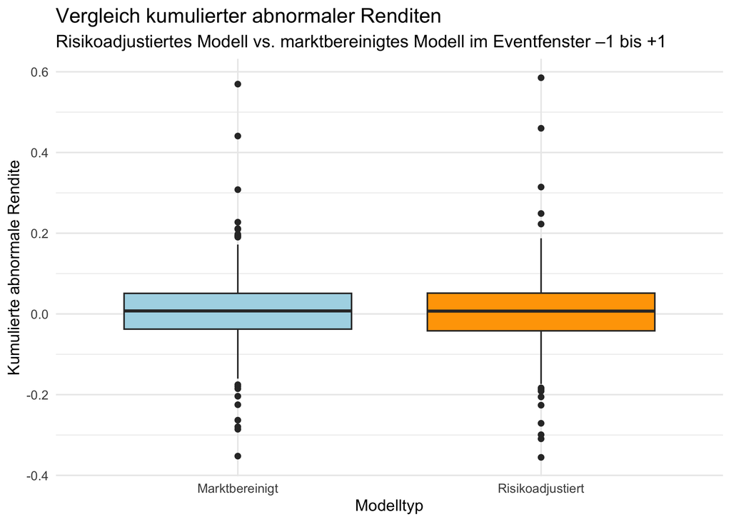

### Vergleich kumulierter abnormaler Renditen: Marktmodell vs. risikoadjustiertes Modell

**Modellbeschreibung**

In der dargestellten Grafik werden die kumulierten abnormalen Renditen im Zeitraum von einem Tag vor bis zu einem Tag nach einem Ereignis mithilfe zweier Modelle verglichen. Das erste Modell basiert auf einem einfachen Marktmodell, bei dem die Marktrendite direkt von der Aktienrendite subtrahiert wird. Das zweite Modell ist ein risikoadjustiertes Verfahren, bei dem die erwartete Rendite mittels einer linearen Regression der individuellen Aktienrendite auf die Marktrendite geschätzt wird. Diese Schätzung erfolgt auf Basis einer vorgelagerten Schätzperiode vor dem Ereignis. Dieser Ansatz entspricht dem sogenannten *Risk-Adjusted Returns Model*, wie es in Huntington-Klein beschrieben ist. Ziel dieses Modells ist eine präzisere Schätzung der erwarteten Rendite unter Berücksichtigung unternehmensspezifischer Sensitivitäten gegenüber dem Markt.

**Beobachtungen aus der Grafik**

Die beiden Verteilungen in der Grafik ähneln sich stark, sowohl was den Median als auch die Streuung betrifft. Zwischen den kumulierten abnormalen Renditen des marktadjustierten und des risikoadjustierten Modells sind keine wesentlichen systematischen Unterschiede erkennbar. Die Verteilungen sind symmetrisch, zentriert um ähnliche Werte, und zeigen eine vergleichbare Anzahl an Ausreißern. Dies deutet darauf hin, dass das einfache Marktmodell in diesem Kontext bereits eine ausreichend gute Schätzung der erwarteten Rendite liefert.

**Ursachen für geringe Unterschiede**

Die geringen Unterschiede zwischen beiden Modellen lassen sich auf mehrere Ursachen zurückführen:

1. Ähnliche Beta-Werte: Die betrachteten Aktien weisen im Durchschnitt eine ähnliche Sensitivität gegenüber dem Markt auf. Wenn die Beta-Werte nahe bei eins liegen oder wenig streuen, reduziert sich der Unterschied zwischen den beiden Modellen deutlich.
2. Vorhersehbare Ereignisse: Die gewählten Ereignisse könnten wenig überraschend gewesen sein oder bereits teilweise eingepreist. Dadurch fällt die Anpassung der erwarteten Rendite im risikoadjustierten Modell gering aus.
3. Kurzes Eventfenster: Das betrachtete Eventfenster ist mit nur drei Tagen sehr kurz. In diesem Zeitraum sind kurzfristige Schwankungen stärker vom allgemeinen Marktverhalten geprägt und lassen weniger Raum für unternehmensspezifische Risikoeffekte.

**Theoretische Einordnung**

Aus theoretischer Sicht lässt sich dieser Befund im Rahmen der Effizienzmarkthypothese einordnen. In einem semi-effizienten Markt, in dem Informationen schnell in die Preise einfließen, spiegelt die Marktrendite bereits einen wesentlichen Teil der erwarteten Aktienrenditen wider. Dementsprechend ist es nicht überraschend, dass das einfache Marktmodell ähnliche Ergebnisse liefert wie das komplexere, individualisierte Modell.

**Fazit**

Die Grafik zeigt insgesamt, dass es in diesem Datensatz keine substanziellen Unterschiede zwischen den beiden Modellansätzen gibt. Der Einsatz des risikoadjustierten Modells ist methodisch korrekt und theoretisch besser fundiert, führt hier jedoch nur zu marginalen Vorteilen. Dies unterstreicht zugleich die Praktikabilität des einfachen Marktmodells bei der Analyse kurzfristiger Ereignisfenster in relativ stabilen Marktphasen.

19. Erstellen Sie die Grafik von Aufgabe 12 neu.

Beschreiben und interpretieren Sie ihre Grafik. Gehen Sie auch auf folgende Fragen ein:

- Könnte es zu Problemen führen, wenn in der Schätzperiode vor dem Event ein weiterer Earnings-Conference Call enthalten ist?
  - Warum könnte dies ein Problem sein, oder warum nicht?

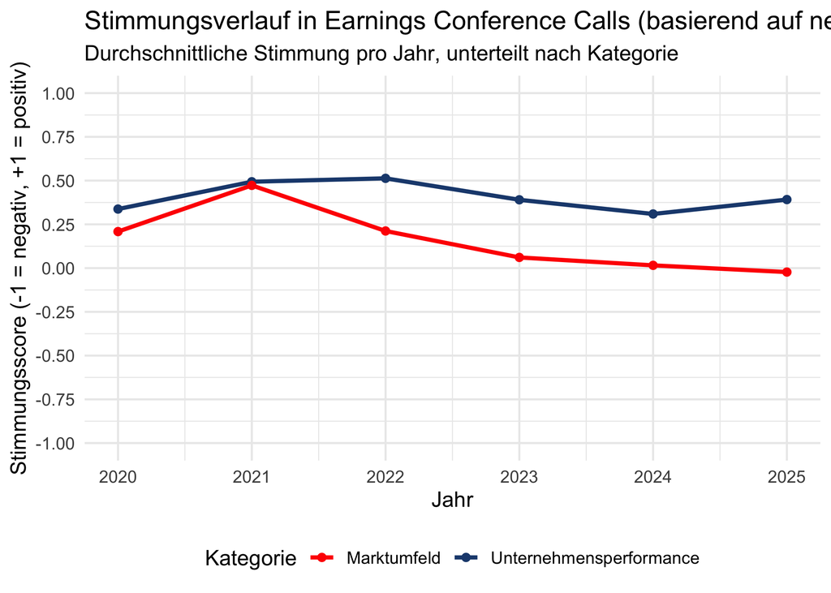

### Entwicklung des Sentiments in Earnings Conference Calls (2020–2025)

**Darstellung der Grafik**

Die neu erstellte Grafik zeigt den durchschnittlichen Sentiment-Score aller Earnings Conference Calls pro Jahr im Zeitraum von 2020 bis 2025, getrennt nach den beiden Kategorien Unternehmensperformance und Marktumfeld. Der Sentiment-Wert bewegt sich auf einer Skala von minus eins bis plus eins, wobei höhere Werte eine positivere Stimmung anzeigen. Die Zeitachse verläuft horizontal über die sechs Jahre hinweg.

**Zeitliche Einordnung und ökonomischer Kontext**

Die Entwicklung der Stimmung in beiden Kategorien lässt sich gut mit den realwirtschaftlichen Ereignissen der letzten Jahre erklären:

*2020: Gedämpfte Stimmung durch Corona-Auswirkungen*

Die Stimmung war durch die Auswirkungen der Corona-Pandemie geprägt. Unsicherheiten, globale Lieferkettenprobleme und ein Nachfragerückgang spielten dabei eine Rolle. Dennoch blieben die durchschnittlichen Sentiment-Werte leicht positiv, was auf eine vorsichtig optimistische Kommunikation der Unternehmen hindeutet.

*2021: Wirtschaftliche Erholung hebt die Stimmung*

Die deutliche Verbesserung der Lage führte zu einem Anstieg der Sentiment-Werte. Die wirtschaftliche Erholung setzte ein, Unternehmen konnten sich besser anpassen und die Normalisierung globaler Prozesse trug zu einer insgesamt positiven Wahrnehmung bei.

*2022–2023: Einbruch im Marktsentiment trotz stabiler Unternehmensperspektiven*

Insbesondere beim Marktumfeld setzte ein Rückgang der Stimmung ein. Ursachen hierfür waren unter anderem der Krieg in der Ukraine, steigende Energiepreise, geopolitische Spannungen und wirtschaftliche Unsicherheiten. Im Jahr 2023 belasteten zudem hohe Inflationsraten und eine schwankende Geldpolitik die Stimmung. Die Einschätzung der Unternehmensleistung blieb hingegen vergleichsweise stabil.

*2024–2025: Stabile Unternehmen – Unsicheres Marktumfeld*

Die Stimmung bezüglich der Unternehmensleistung verbessert sich wieder. Dies deutet auf eine zunehmende operative Stabilität und Resilienz der Unternehmen hin. Das Marktumfeld bleibt hingegen auf einem niedrigeren Niveau, was auf anhaltende externe Unsicherheiten zurückzuführen ist.

**Methodische Herausforderungen bei der Sentiment-Analyse**

*Einfluss früherer Earnings Calls in der Schätzperiode*

Im Zusammenhang mit dieser Grafik stellt sich die Frage, ob es problematisch sein kann, wenn sich in der Schätzperiode vor einem Earnings-Conference-Call bereits ein weiterer Call befindet. Diese Frage lässt sich klar mit Ja beantworten.

Die Schätzperiode dient dazu, ein neutrales Ausgangsniveau des Sentiments, also die Stimmungslage vor dem eigentlichen Ereignis, zu ermitteln. Enthält diese Periode jedoch bereits einen früheren Call, besteht die Gefahr, dass dieser die Stimmung beeinflusst und somit die Vergleichsbasis verzerrt.

*Beispiel zur Veranschaulichung*

Ein Beispiel verdeutlicht dies: Wenn ein Unternehmen in einem früheren Call optimistische Aussagen zur Geschäftsentwicklung trifft und dieser Call in der Schätzperiode enthalten ist, beeinflusst das bereits den durchschnittlichen Sentiment-Wert vor dem neuen Ereignis. Findet wenige Wochen später ein weiterer Call statt, wird dieser nicht mehr mit einem neutralen Vorher-Wert verglichen, sondern mit einem bereits positiv gefärbten Durchschnitt. Dadurch kann der Effekt des neuen Events unterschätzt oder überlagert werden.

In der dargestellten Grafik wird zudem deutlich, dass sich das Sentiment im Zeitverlauf stark verändert und dass äußere Ereignisse einen erheblichen Einfluss haben. Sind solche Einflüsse bereits in der Schätzperiode präsent – etwa durch einen vorangegangenen Call, der auf makroökonomische Unsicherheiten reagiert –, ist eine saubere Trennung zwischen Schätz- und Eventzeitraum nicht mehr gewährleistet.

*Besonderheiten bei häufigen Calls*

Dieses Problem ist besonders kritisch bei Unternehmen, die innerhalb eines Jahres mehrere Earnings Calls veröffentlichen. In solchen Fällen steigt das Risiko, dass Aussagen aus einem früheren Call noch in die Schätzperiode des nächsten Calls fallen. Dadurch entsteht eine methodische Verzerrung, da die beiden Calls dann nicht mehr unabhängig voneinander sind. Dies widerspricht dem Grundprinzip der Ereignisanalyse, welches auf einer klaren zeitlichen Trennung zwischen Referenzzeitraum und Eventzeitpunkt basiert.

*Fazit*

Zusammenfassend lässt sich sagen, dass die Berücksichtigung eines weiteren Earnings Conference Calls in der Schätzperiode zu einer verfälschten Bewertung des eigentlichen Events führen kann. Um verlässliche Ergebnisse zu erhalten, sollte die Schätzperiode frei von solchen vorhergehenden Ereignissen sein. Nur so lässt sich der Einfluss des aktuellen Calls klar erkennen und interpretieren.

20. Lesen Sie das Kapitel [“Fixed Effects” in Huntington-Klein (2021)](https://theeffectbook.net/ch-FixedEffects.html#how-does-it-work), speziell Kapitel 16.1
21. Regressieren Sie die `cmar_101` auf die Variablen *negativ_firm* und *negativ_market* und kontrollieren Sie auf die Größe des jeweiligen Unternehmens, indem Sie die Variable *Total_Assets* in ihre Regression aufnehmen. Kontrollieren Sie weiterhin auf das Jahr in dem das Event stattgefunden hat. Fügen Sie weiterhin der Regression Firmen-Fixe Effekte hinzu.

Beschreiben und interpretieren Sie ihre Ergebnisse.

Gehen Sie zusätzlich auf die folgenden Frage ein:

- Was sind Firmen-Fixe Effekte und warum könnten diese für ihre Regression sinnvoll sein?

*Hinweis:* Mit dem [Paket `fixest`](https://cran.r-project.org/web/packages/fixest/vignettes/fixest_walkthrough.html) und der Funktion feols() können Sie einfach ihren Regressionen fixe Effekte hinzufügen

**Regression der kumulierten abnormalen Renditen**

Einfluss negativer Stimmung, Unternehmensgröße und Jahr mit Firmen-Fixed-Effects

|  | Fixed Effects Modell |
| --- | --- |
| Negative Stimmung (Firma) | -0.047 |
|  | (0.032) |
| Negative Stimmung (Markt) | -0.014 |
|  | (0.014) |
| Unternehmensgröße (Total Assets) | 0.000 |
|  | (0.000) |
| Jahr: 2021 | -0.020 |
|  | (0.014) |
| Jahr: 2022 | -0.011 |
|  | (0.011) |
| Jahr: 2023 | -0.012 |
|  | (0.017) |
| Jahr: 2024 | -0.029* |
|  | (0.012) |
| Jahr: 2025 | -0.014 |
|  | (0.012) |
| Num.Obs. | 2601 |
| R2 | 0.107 |
| R2 Adj. | 0.094 |

* p < 0.05, ** p < 0.01, *** p < 0.001

### Einfluss negativer Stimmung auf kumulierte abnormalen Renditen: Eine Paneldatenanalyse mit Fixed Effects

**Ziel der Analyse**

Die Regression untersucht den Einfluss negativer Stimmung auf Unternehmensebene sowie auf gesamtwirtschaftlicher Marktebene auf die kumulierten abnormalen Renditen. Dabei wird die Unternehmensgröße, die durch die Variable „Total Assets” erfasst wird, zusätzlich berücksichtigt. Zudem wird der Einfluss des jeweiligen Jahres berücksichtigt, indem Jahrgangsdummies für die Jahre 2021 bis 2025 in das Modell aufgenommen wurden.

Zur Kontrolle unbeobachteter, firmenspezifischer, zeitlich konstanter Eigenschaften wurden feste Effekte für die einzelnen Unternehmen eingefügt. Die Analyse basiert auf einer Stichprobe von insgesamt 2.601 Beobachtungen. Das Bestimmtheitsmaß (R²) beträgt etwa 0,107, das adjustierte R² liegt bei 0,094. Dies ist für Paneldaten mit fixen Effekten typisch und gibt Auskunft über die erklärte Varianz des Modells.

**Schätzergebnisse**

Die geschätzten Koeffizienten zeigen, dass eine negative Stimmung auf Unternehmensebene tendenziell zu niedrigeren kumulierten abnormalen Renditen führt. Der entsprechende Wert beträgt –0,047. Dieser Effekt ist jedoch nicht statistisch signifikant. Auch die negative Stimmung auf Marktebene weist mit einem Koeffizienten von –0,014 keinen signifikanten Effekt auf.

**Interpretation der Ergebnisse**

Die Ergebnisse lassen darauf schließen, dass eine negative Stimmung gegenüber einem Unternehmen mit niedrigeren kumulierten abnormalen Renditen einhergehen kann. Der Effekt bewegt sich in die erwartete Richtung, ist mit einem Wert von –0,047 jedoch nicht signifikant. Es kann daher keine belastbare Aussage über einen kausalen Zusammenhang getroffen werden.

Auch die negative Stimmung auf Marktebene zeigt mit –0,014 keinen signifikanten Effekt. Dies kann entweder bedeuten, dass die allgemeine Marktstimmung in der betrachteten Periode keine systematische Auswirkung auf die abnormalen Renditen hatte oder dass andere Faktoren diese Wirkung überlagert haben.

Die Unternehmensgröße, gemessen an den Total Assets, hat ebenfalls keinen relevanten Einfluss auf die Renditen. Dies legt nahe, dass sie die Marktreaktionen in diesem Zeitraum nicht maßgeblich beeinflusst hat.

**Bedeutung der Firmen-Fixed-Effects**

Insbesondere der Einbezug von Firmen-Fixed-Effects ist wichtig, um unbeobachtete, zeitlich konstante Merkmale einzelner Unternehmen auszuschließen. Solche Merkmale könnten die Schätzungen verzerren, da sie mit den unabhängigen Variablen sowie mit den abnormalen Renditen korrelieren können. Die festen Effekte gewährleisten, dass die Effekte negativer Stimmung, Unternehmensgröße und zeitlicher Einflüsse unabhängig von firmenspezifischen, konstanten Faktoren isoliert und geschätzt werden können.

**Kontrolle zeitlicher Effekte**

Die Kontrolle durch die Jahrgangsdummies berücksichtigt allgemeine zeitliche Trends oder externe Ereignisse, von denen alle Unternehmen gleichermaßen betroffen sein könnten. Die Koeffizienten für die Jahre 2021 bis 2025 liegen nahe null. Einzig das Jahr 2024 zeigt mit −0,029 einen signifikanten negativen Effekt (p < 0,05). Dies könnte auf ein spezifisches Ereignis oder ein schwächeres Marktumfeld in diesem Jahr hindeuten. Die übrigen Jahresdummies sind nicht signifikant, was darauf hindeutet, dass es keine systematischen Schwankungen der abnormalen Renditen in den übrigen Jahren gab.

**Fazit**

Zusammenfassend zeigen die Befunde, dass negative Stimmung zwar tendenziell einen Einfluss auf kumulierte abnormale Renditen hat, dieser Einfluss ist jedoch nicht statistisch signifikant. Weder die Unternehmensgröße noch die allgemeine Marktstimmung haben einen relevanten oder signifikanten Effekt. Durch die Verwendung von Fixed Effects und Jahrgangskontrollen werden robuste Schätzungen ermöglicht und die Effekte sauber voneinander getrennt. Lediglich das Jahr 2024 hebt sich durch einen eigenständigen, signifikanten Einfluss ab.

# Literatur

- Kapitel Event Studies im Buch [The Effect Book: Event Studies](https://theeffectbook.net/ch-EventStudies.html)
- Kapitel Fixe Effekte im Buch [The Effect Book: Event Studies](https://theeffectbook.net/ch-FixedEffects.html)
- [Paket `fixest`](https://cran.r-project.org/web/packages/fixest/vignettes/fixest_walkthrough.html)

# Anhang

## Prompt Arten

Prompt-Arten unterscheiden sich in der Anzahl der Beispiele, die Sie dem KI-Modell geben:

**Zero-Shot Prompt**

- Keine Beispiele gegeben
- Nur die Aufgabe wird beschrieben
- Beispiel: “Übersetze ins Englische: Guten Morgen”

**One-Shot Prompt**

- Ein einziges Beispiel wird gezeigt
- Das Modell lernt aus diesem einen Beispiel
- Beispiel: “Übersetze ins Englische:

Guten Tag → Good day Guten Morgen → ?”

**Few-Shot Prompt**

- Mehrere Beispiele werden gegeben (typisch 2-5)
- Das Modell kann aus mehreren Mustern lernen
- Beispiel: “Übersetze ins Englische:

Guten Tag → Good day Auf Wiedersehen → Goodbye Danke → Thank you Guten Morgen → ?”